# CBTI Summary

## Consort map

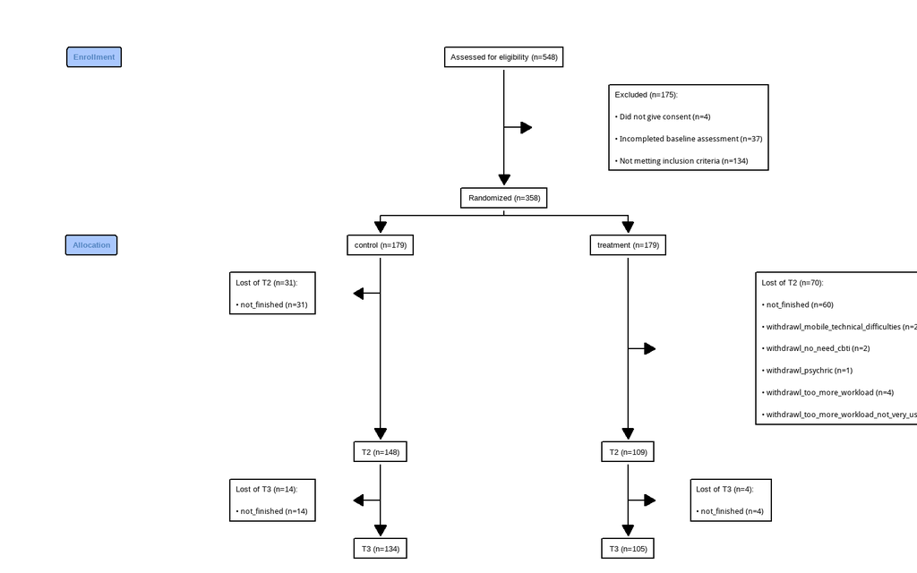

## Demographic information

| Characteristic | N | Overall, N = 358 | control, N = 179 | treatment, N = 179 | p-value |
| --- | --- | --- | --- | --- | --- |
| age | 358 | 36.34 ± 13.94 (18 - 73) | 35.95 ± 13.84 (18 - 73) | 36.72 ± 14.07 (18 - 71) | 0.599 |
| gender | 358 |  |  |  | 0.792 |
| female |  | 286 (80%) | 142 (79%) | 144 (80%) |  |
| male |  | 72 (20%) | 37 (21%) | 35 (20%) |  |
| occupation | 358 |  |  |  | 0.658 |
| civil |  | 13 (3.6%) | 4 (2.2%) | 9 (5.0%) |  |
| clerk |  | 57 (16%) | 30 (17%) | 27 (15%) |  |
| craft |  | 12 (3.4%) | 8 (4.5%) | 4 (2.2%) |  |
| homemaker |  | 26 (7.3%) | 14 (7.8%) | 12 (6.7%) |  |
| manager |  | 28 (7.8%) | 16 (8.9%) | 12 (6.7%) |  |
| other |  | 15 (4.2%) | 5 (2.8%) | 10 (5.6%) |  |
| professional |  | 39 (11%) | 16 (8.9%) | 23 (13%) |  |
| retired |  | 21 (5.9%) | 10 (5.6%) | 11 (6.1%) |  |
| service |  | 12 (3.4%) | 7 (3.9%) | 5 (2.8%) |  |
| student |  | 119 (33%) | 60 (34%) | 59 (33%) |  |
| unemploy |  | 16 (4.5%) | 9 (5.0%) | 7 (3.9%) |  |
| marital | 358 |  |  |  | 0.652 |
| divorced |  | 14 (3.9%) | 5 (2.8%) | 9 (5.0%) |  |
| married |  | 97 (27%) | 51 (28%) | 46 (26%) |  |
| other |  | 2 (0.6%) | 1 (0.6%) | 1 (0.6%) |  |
| separated |  | 5 (1.4%) | 1 (0.6%) | 4 (2.2%) |  |
| single |  | 235 (66%) | 119 (66%) | 116 (65%) |  |
| widowed |  | 5 (1.4%) | 2 (1.1%) | 3 (1.7%) |  |
| education | 358 |  |  |  | 0.914 |
| post-secondary |  | 52 (15%) | 28 (16%) | 24 (13%) |  |
| primary |  | 2 (0.6%) | 1 (0.6%) | 1 (0.6%) |  |
| secondary |  | 50 (14%) | 24 (13%) | 26 (15%) |  |
| university |  | 254 (71%) | 126 (70%) | 128 (72%) |  |
| family_income | 358 |  |  |  | 0.502 |
| 0_10000 |  | 56 (16%) | 27 (15%) | 29 (16%) |  |
| 10001_20000 |  | 75 (21%) | 38 (21%) | 37 (21%) |  |
| 20001_30000 |  | 73 (20%) | 42 (23%) | 31 (17%) |  |
| 30001_40000 |  | 60 (17%) | 31 (17%) | 29 (16%) |  |
| 40000_above |  | 94 (26%) | 41 (23%) | 53 (30%) |  |
| religion | 358 |  |  |  | 0.110 |
| buddhism |  | 16 (4.5%) | 7 (3.9%) | 9 (5.0%) |  |
| catholic |  | 17 (4.7%) | 11 (6.1%) | 6 (3.4%) |  |
| christianity |  | 73 (20%) | 30 (17%) | 43 (24%) |  |
| nil |  | 248 (69%) | 130 (73%) | 118 (66%) |  |
| other |  | 3 (0.8%) | 0 (0%) | 3 (1.7%) |  |
| taoism |  | 1 (0.3%) | 1 (0.6%) | 0 (0%) |  |
| source | 358 |  |  |  | 0.233 |
| bokss |  | 15 (4.2%) | 11 (6.1%) | 4 (2.2%) |  |
| facebook |  | 131 (37%) | 63 (35%) | 68 (38%) |  |
| instagram |  | 12 (3.4%) | 7 (3.9%) | 5 (2.8%) |  |
| other |  | 66 (18%) | 28 (16%) | 38 (21%) |  |
| refresh |  | 134 (37%) | 70 (39%) | 64 (36%) |  |

1Mean ± SD (Range); n (%)  
2Two Sample t-test; Pearson's Chi-squared test; Fisher's exact test

## Measurement

### Table

| Characteristic | N | Overall, N = 358 | control, N = 179 | treatment, N = 179 | p-value |
| --- | --- | --- | --- | --- | --- |
| isi | 358 | 13.47 ± 3.37 (8 - 21) | 13.53 ± 3.33 (8 - 21) | 13.40 ± 3.42 (8 - 21) | 0.719 |
| who | 358 | 9.90 ± 3.74 (0 - 21) | 9.82 ± 3.71 (1 - 20) | 9.98 ± 3.77 (0 - 21) | 0.682 |
| phq | 358 | 8.51 ± 5.01 (0 - 25) | 8.21 ± 4.98 (0 - 21) | 8.80 ± 5.03 (0 - 25) | 0.264 |
| gad | 358 | 7.78 ± 5.12 (0 - 21) | 7.54 ± 5.03 (0 - 21) | 8.02 ± 5.21 (0 - 21) | 0.376 |
| wsas | 358 | 16.73 ± 9.85 (0 - 40) | 16.77 ± 9.70 (0 - 39) | 16.69 ± 10.03 (0 - 40) | 0.936 |
| shps_arousal | 358 | 3.10 ± 0.69 (1 - 5) | 3.02 ± 0.68 (1 - 5) | 3.18 ± 0.69 (1 - 5) | 0.025 |
| shps_schedule | 358 | 3.55 ± 0.87 (1 - 6) | 3.53 ± 0.81 (2 - 6) | 3.58 ± 0.93 (1 - 6) | 0.653 |
| shps_behavior | 358 | 2.05 ± 0.66 (1 - 4) | 1.99 ± 0.61 (1 - 4) | 2.12 ± 0.71 (1 - 4) | 0.059 |
| shps_environment | 358 | 2.30 ± 0.82 (1 - 5) | 2.33 ± 0.84 (1 - 5) | 2.27 ± 0.80 (1 - 5) | 0.473 |
| dbas_consequence | 358 | 6.61 ± 1.75 (1 - 10) | 6.59 ± 1.82 (1 - 10) | 6.64 ± 1.68 (1 - 10) | 0.772 |
| dbas_worry | 358 | 14.37 ± 3.23 (3 - 20) | 14.20 ± 3.35 (3 - 20) | 14.54 ± 3.11 (3 - 20) | 0.319 |
| dbas_expectation | 358 | 7.03 ± 2.14 (1 - 10) | 7.17 ± 2.09 (1 - 10) | 6.89 ± 2.19 (1 - 10) | 0.209 |
| dbas_medication | 358 | 3.19 ± 2.07 (0 - 9) | 3.15 ± 2.04 (0 - 9) | 3.24 ± 2.09 (0 - 9) | 0.683 |
| psas_somatic | 358 | 1.88 ± 0.69 (1 - 5) | 1.86 ± 0.66 (1 - 4) | 1.91 ± 0.71 (1 - 5) | 0.539 |
| psas_cognitive | 358 | 2.92 ± 0.85 (1 - 5) | 2.87 ± 0.84 (1 - 5) | 2.97 ± 0.86 (1 - 5) | 0.270 |
| psqi_global | 358 | 10.87 ± 3.02 (2 - 19) | 10.72 ± 3.03 (4 - 17) | 11.01 ± 3.00 (2 - 19) | 0.363 |
| mic_attention | 358 | 1.36 ± 0.72 (0 - 3) | 1.30 ± 0.71 (0 - 3) | 1.42 ± 0.73 (0 - 3) | 0.110 |
| mic_executive | 358 | 1.31 ± 0.76 (0 - 3) | 1.28 ± 0.77 (0 - 3) | 1.35 ± 0.76 (0 - 3) | 0.406 |
| mic_memory | 358 | 1.37 ± 0.73 (0 - 3) | 1.33 ± 0.75 (0 - 3) | 1.40 ± 0.71 (0 - 3) | 0.397 |
| nb_pcs | 358 | 46.27 ± 8.63 (17 - 65) | 46.33 ± 8.91 (17 - 63) | 46.20 ± 8.38 (21 - 65) | 0.879 |
| nb_mcs | 358 | 39.94 ± 9.95 (8 - 65) | 39.90 ± 9.78 (8 - 62) | 39.98 ± 10.14 (8 - 65) | 0.935 |

1Mean ± SD (Range)  
2Two Sample t-test

### Plot

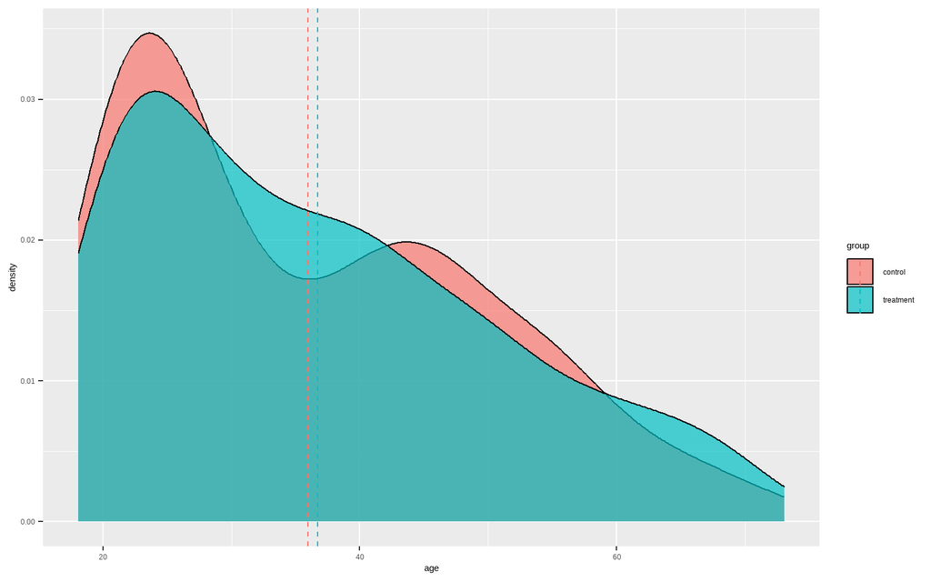

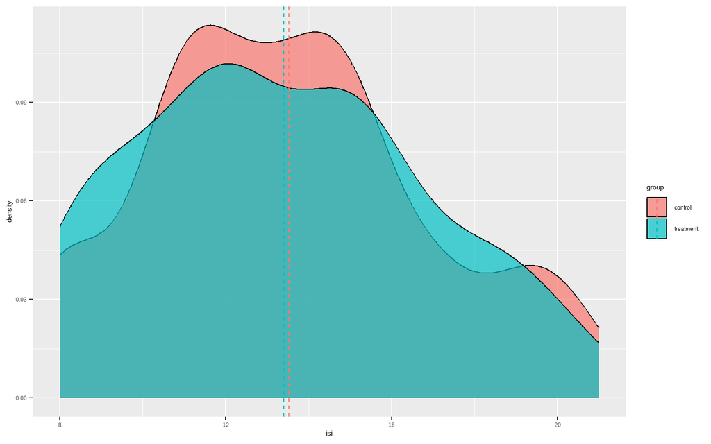

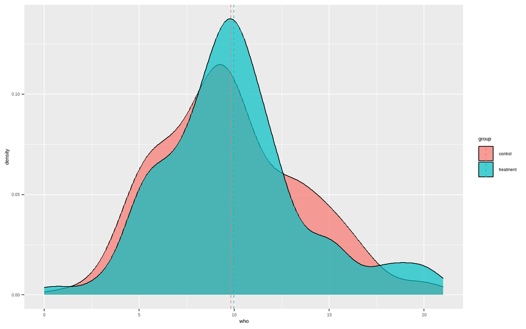

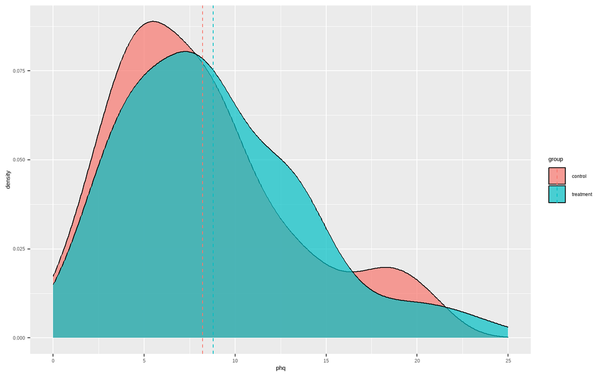

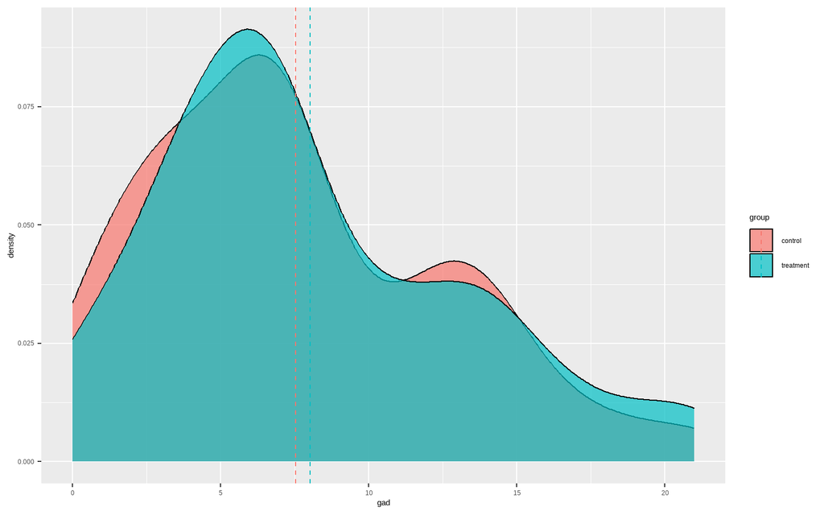

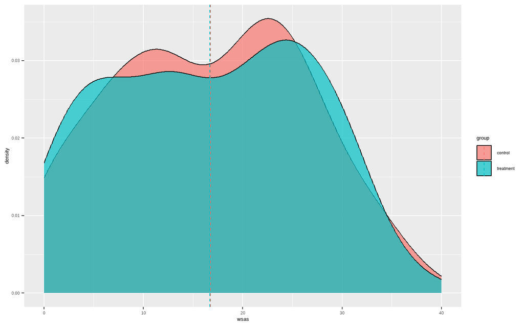

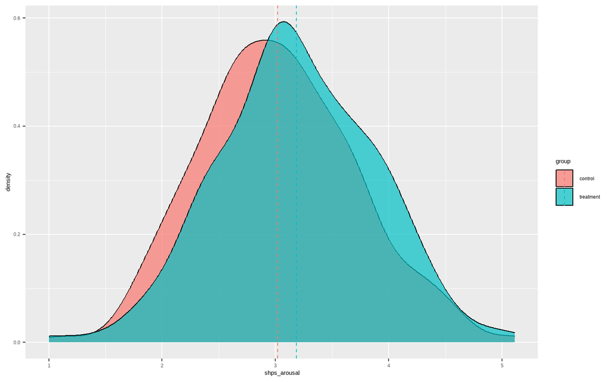

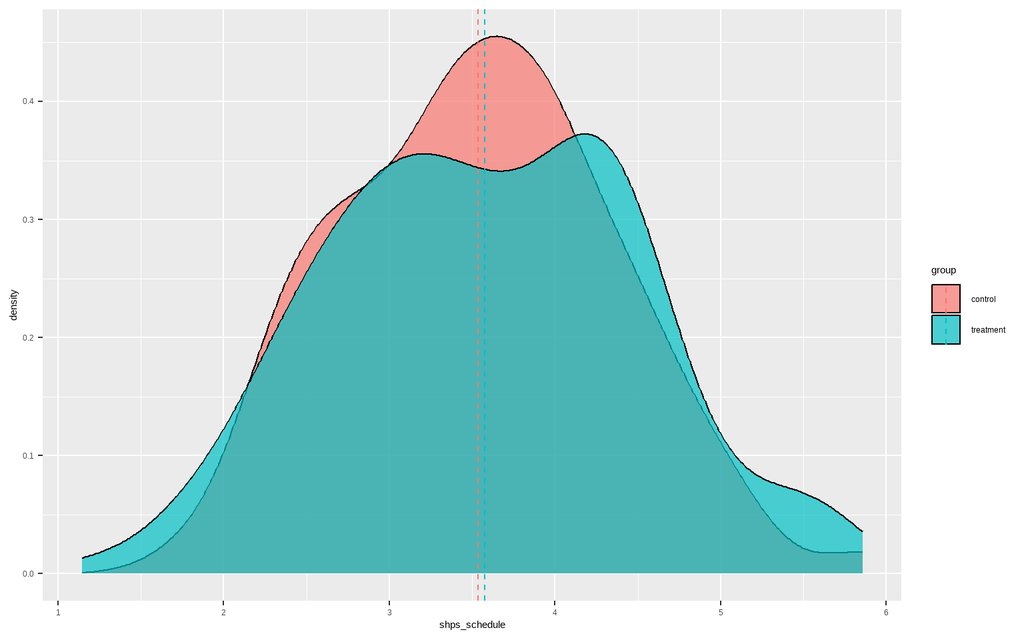

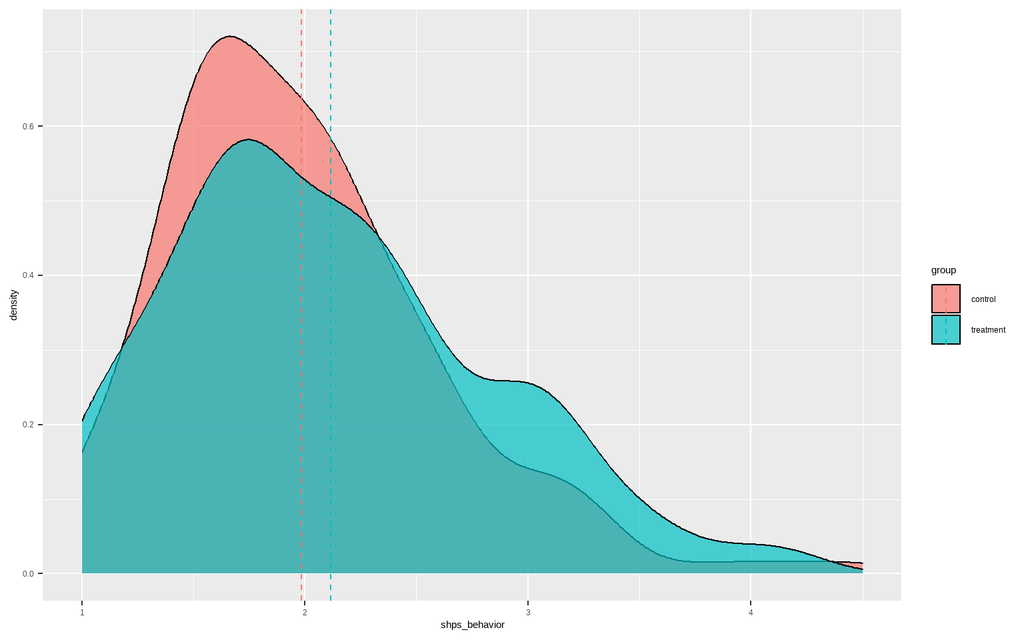

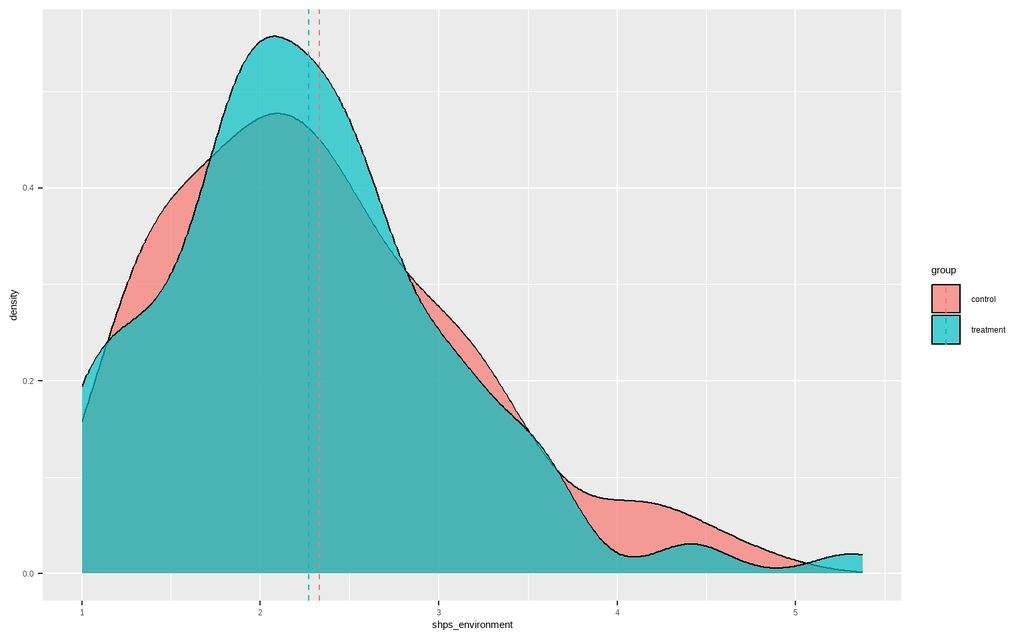

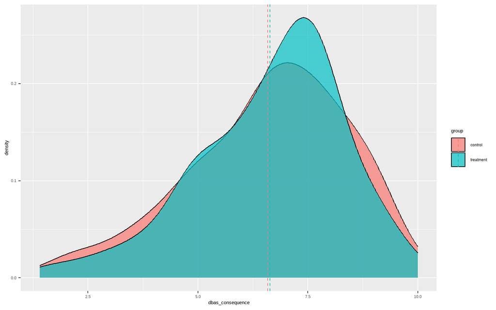

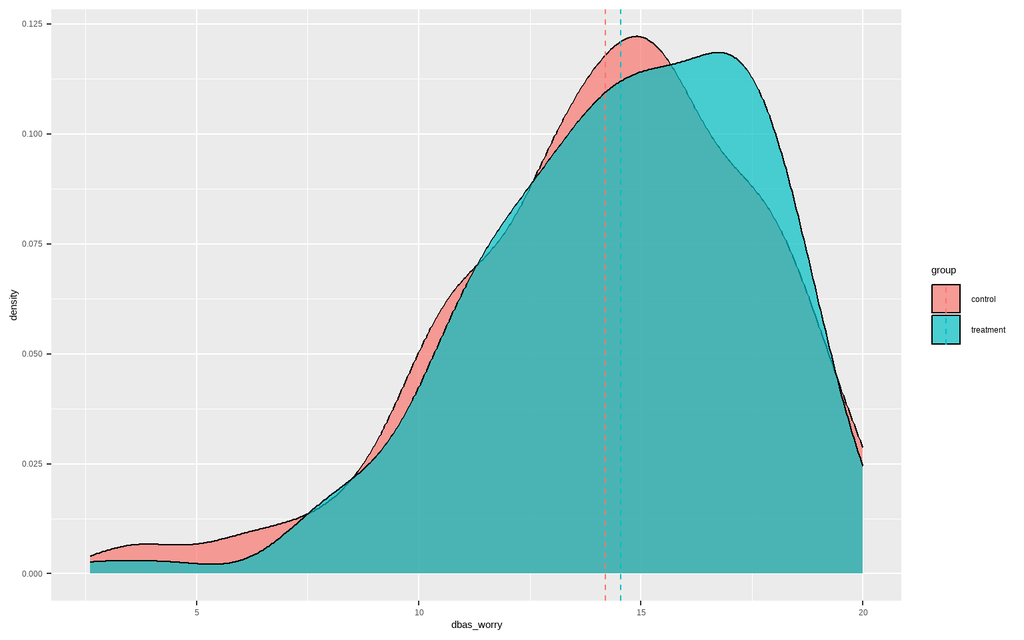

[10 more figures not shown]

## Data analysis

### Table

| Group | Characteristic | Beta | SE1 | 95% CI1 | p-value |
| --- | --- | --- | --- | --- | --- |
| isi | (Intercept) | 13.5 | 0.285 | 13.0, 14.1 |  |
|  | group |  |  |  |  |
|  | control | — | — | — |  |
|  | treatment | -0.128 | 0.403 | -0.918, 0.661 | 0.750 |
|  | time_point |  |  |  |  |
|  | 1st | — | — | — |  |
|  | 2nd | -2.46 | 0.320 | -3.09, -1.83 | 0.000 |
|  | 3rd | -2.84 | 0.332 | -3.49, -2.19 | 0.000 |
|  | group * time_point |  |  |  |  |
|  | treatment * 2nd | -2.96 | 0.483 | -3.91, -2.01 | 0.000 |
|  | treatment * 3rd | -2.99 | 0.494 | -3.96, -2.02 | 0.000 |
|  | Pseudo R square | 0.261 |  |  |  |
| who | (Intercept) | 9.82 | 0.305 | 9.22, 10.4 |  |
|  | group |  |  |  |  |
|  | control | — | — | — |  |
|  | treatment | 0.162 | 0.432 | -0.684, 1.01 | 0.708 |
|  | time_point |  |  |  |  |
|  | 1st | — | — | — |  |
|  | 2nd | 0.729 | 0.300 | 0.142, 1.32 | 0.015 |
|  | 3rd | 0.935 | 0.310 | 0.327, 1.54 | 0.003 |
|  | group * time_point |  |  |  |  |
|  | treatment * 2nd | 1.40 | 0.454 | 0.512, 2.29 | 0.002 |
|  | treatment * 3rd | 1.62 | 0.465 | 0.712, 2.53 | 0.001 |
|  | Pseudo R square | 0.054 |  |  |  |
| phq | (Intercept) | 8.21 | 0.378 | 7.47, 8.95 |  |
|  | group |  |  |  |  |
|  | control | — | — | — |  |
|  | treatment | 0.592 | 0.535 | -0.456, 1.64 | 0.269 |
|  | time_point |  |  |  |  |
|  | 1st | — | — | — |  |

[output cut: 222 more lines]

1SE = Standard Error, CI = Confidence Interval

### Text

**isi**

We fitted a linear mixed model (estimated using REML and nloptwrap optimizer) to predict isi with group and time_point (formula: isi ~ 1 + group + time_point + group * time_point). The model included login_id as random effect (formula: ~1 | login_id). The model’s total explanatory power is substantial (conditional R2 = 0.60) and the part related to the fixed effects alone (marginal R2) is of 0.26. The model’s intercept, corresponding to group = control and time_point = 1st , is at 13.53 (95% CI [12.97, 14.09], t(846) = 47.48, p < .001). Within this model:

- The effect of group [treatment] is statistically non-significant and negative (beta = -0.13, 95% CI [-0.92, 0.66], t(846) = -0.32, p = 0.750; Std. beta = -0.03, 95% CI [-0.21, 0.15])
- The effect of time point [2nd] is statistically significant and negative (beta = -2.46, 95% CI [-3.09, -1.83], t(846) = -7.67, p < .001; Std. beta = -0.55, 95% CI [-0.69, -0.41])
- The effect of time point [3rd] is statistically significant and negative (beta = -2.84, 95% CI [-3.49, -2.19], t(846) = -8.57, p < .001; Std. beta = -0.64, 95% CI [-0.78, -0.49])
- The interaction effect of time point [2nd] on group [treatment] is statistically significant and negative (beta = -2.96, 95% CI [-3.91, -2.01], t(846) = -6.13, p < .001; Std. beta = -0.66, 95% CI [-0.87, -0.45])
- The interaction effect of time point [3rd] on group [treatment] is statistically significant and negative (beta = -2.99, 95% CI [-3.96, -2.02], t(846) = -6.05, p < .001; Std. beta = -0.67, 95% CI [-0.88, -0.45])

Standardized parameters were obtained by fitting the model on a standardized version of the dataset. 95% Confidence Intervals (CIs) and p-values were computed using a Wald normal distribution approximation.

**who**

We fitted a linear mixed model (estimated using REML and nloptwrap optimizer) to predict who with group and time_point (formula: who ~ 1 + group + time_point + group * time_point). The model included login_id as random effect (formula: ~1 | login_id). The model’s total explanatory power is substantial (conditional R2 = 0.61) and the part related to the fixed effects alone (marginal R2) is of 0.05. The model’s intercept, corresponding to group = control and time_point = 1st , is at 9.82 (95% CI [9.22, 10.42], t(846) = 32.18, p < .001). Within this model:

- The effect of group [treatment] is statistically non-significant and positive (beta = 0.16, 95% CI [-0.68, 1.01], t(846) = 0.38, p = 0.707; Std. beta = 0.04, 95% CI [-0.16, 0.24])
- The effect of time point [2nd] is statistically significant and positive (beta = 0.73, 95% CI [0.14, 1.32], t(846) = 2.43, p = 0.015; Std. beta = 0.17, 95% CI [0.03, 0.31])
- The effect of time point [3rd] is statistically significant and positive (beta = 0.94, 95% CI [0.33, 1.54], t(846) = 3.01, p = 0.003; Std. beta = 0.22, 95% CI [0.08, 0.37])
- The interaction effect of time point [2nd] on group [treatment] is statistically significant and positive (beta = 1.40, 95% CI [0.51, 2.29], t(846) = 3.09, p = 0.002; Std. beta = 0.33, 95% CI [0.12, 0.54])
- The interaction effect of time point [3rd] on group [treatment] is statistically significant and positive (beta = 1.62, 95% CI [0.71, 2.53], t(846) = 3.49, p < .001; Std. beta = 0.38, 95% CI [0.17, 0.60])

Standardized parameters were obtained by fitting the model on a standardized version of the dataset. 95% Confidence Intervals (CIs) and p-values were computed using a Wald normal distribution approximation.

**phq**

We fitted a linear mixed model (estimated using REML and nloptwrap optimizer) to predict phq with group and time_point (formula: phq ~ 1 + group + time_point + group * time_point). The model included login_id as random effect (formula: ~1 | login_id). The model’s total explanatory power is substantial (conditional R2 = 0.68) and the part related to the fixed effects alone (marginal R2) is of 0.04. The model’s intercept, corresponding to group = control and time_point = 1st , is at 8.21 (95% CI [7.47, 8.95], t(846) = 21.71, p < .001). Within this model:

- The effect of group [treatment] is statistically non-significant and positive (beta = 0.59, 95% CI [-0.46, 1.64], t(846) = 1.11, p = 0.268; Std. beta = 0.11, 95% CI [-0.09, 0.32])
- The effect of time point [2nd] is statistically significant and negative (beta = -0.78, 95% CI [-1.43, -0.12], t(846) = -2.33, p = 0.020; Std. beta = -0.15, 95% CI [-0.28, -0.02])
- The effect of time point [3rd] is statistically non-significant and negative (beta = -0.63, 95% CI [-1.30, 0.05], t(846) = -1.81, p = 0.070; Std. beta = -0.12, 95% CI [-0.25, 0.01])
- The interaction effect of time point [2nd] on group [treatment] is statistically significant and negative (beta = -1.73, 95% CI [-2.73, -0.74], t(846) = -3.42, p < .001; Std. beta = -0.33, 95% CI [-0.53, -0.14])
- The interaction effect of time point [3rd] on group [treatment] is statistically significant and negative (beta = -2.46, 95% CI [-3.48, -1.44], t(846) = -4.74, p < .001; Std. beta = -0.47, 95% CI [-0.67, -0.28])

Standardized parameters were obtained by fitting the model on a standardized version of the dataset. 95% Confidence Intervals (CIs) and p-values were computed using a Wald normal distribution approximation.

**gad**

We fitted a linear mixed model (estimated using REML and nloptwrap optimizer) to predict gad with group and time_point (formula: gad ~ 1 + group + time_point + group * time_point). The model included login_id as random effect (formula: ~1 | login_id). The model’s total explanatory power is substantial (conditional R2 = 0.67) and the part related to the fixed effects alone (marginal R2) is of 0.04. The model’s intercept, corresponding to group = control and time_point = 1st , is at 7.54 (95% CI [6.79, 8.28], t(846) = 19.77, p < .001). Within this model:

- The effect of group [treatment] is statistically non-significant and positive (beta = 0.48, 95% CI [-0.58, 1.54], t(846) = 0.89, p = 0.373; Std. beta = 0.09, 95% CI [-0.11, 0.30])
- The effect of time point [2nd] is statistically non-significant and negative (beta = -0.44, 95% CI [-1.11, 0.23], t(846) = -1.29, p = 0.197; Std. beta = -0.08, 95% CI [-0.21, 0.04])
- The effect of time point [3rd] is statistically non-significant and negative (beta = -0.63, 95% CI [-1.32, 0.07], t(846) = -1.78, p = 0.076; Std. beta = -0.12, 95% CI [-0.26, 0.01])
- The interaction effect of time point [2nd] on group [treatment] is statistically significant and negative (beta = -2.07, 95% CI [-3.09, -1.06], t(846) = -4.00, p < .001; Std. beta = -0.40, 95% CI [-0.60, -0.20])
- The interaction effect of time point [3rd] on group [treatment] is statistically significant and negative (beta = -2.33, 95% CI [-3.37, -1.29], t(846) = -4.40, p < .001; Std. beta = -0.45, 95% CI [-0.65, -0.25])

Standardized parameters were obtained by fitting the model on a standardized version of the dataset. 95% Confidence Intervals (CIs) and p-values were computed using a Wald normal distribution approximation.

**wsas**

We fitted a linear mixed model (estimated using REML and nloptwrap optimizer) to predict wsas with group and time_point (formula: wsas ~ 1 + group + time_point + group * time_point). The model included login_id as random effect (formula: ~1 | login_id). The model’s total explanatory power is substantial (conditional R2 = 0.64) and the part related to the fixed effects alone (marginal R2) is of 0.03. The model’s intercept, corresponding to group = control and time_point = 1st , is at 16.77 (95% CI [15.30, 18.24], t(846) = 22.41, p < .001). Within this model:

- The effect of group [treatment] is statistically non-significant and negative (beta = -0.08, 95% CI [-2.16, 1.99], t(846) = -0.08, p = 0.937; Std. beta = -8.25e-03, 95% CI [-0.21, 0.20])
- The effect of time point [2nd] is statistically non-significant and negative (beta = -0.82, 95% CI [-2.18, 0.55], t(846) = -1.18, p = 0.239; Std. beta = -0.08, 95% CI [-0.22, 0.05])
- The effect of time point [3rd] is statistically non-significant and negative (beta = -0.15, 95% CI [-1.57, 1.26], t(846) = -0.21, p = 0.834; Std. beta = -0.01, 95% CI [-0.15, 0.12])
- The interaction effect of time point [2nd] on group [treatment] is statistically significant and negative (beta = -2.95, 95% CI [-5.02, -0.88], t(846) = -2.79, p = 0.005; Std. beta = -0.29, 95% CI [-0.49, -0.09])
- The interaction effect of time point [3rd] on group [treatment] is statistically significant and negative (beta = -4.88, 95% CI [-7.00, -2.76], t(846) = -4.51, p < .001; Std. beta = -0.48, 95% CI [-0.69, -0.27])

Standardized parameters were obtained by fitting the model on a standardized version of the dataset. 95% Confidence Intervals (CIs) and p-values were computed using a Wald normal distribution approximation.

**shps_arousal**

We fitted a linear mixed model (estimated using REML and nloptwrap optimizer) to predict shps_arousal with group and time_point (formula: shps_arousal ~ 1 + group + time_point + group * time_point). The model included login_id as random effect (formula: ~1 | login_id). The model’s total explanatory power is substantial (conditional R2 = 0.56) and the part related to the fixed effects alone (marginal R2) is of 0.11. The model’s intercept, corresponding to group = control and time_point = 1st , is at 3.02 (95% CI [2.91, 3.13], t(846) = 54.50, p < .001). Within this model:

- The effect of group [treatment] is statistically significant and positive (beta = 0.16, 95% CI [8.94e-03, 0.32], t(846) = 2.07, p = 0.038; Std. beta = 0.21, 95% CI [0.01, 0.40])
- The effect of time point [2nd] is statistically significant and negative (beta = -0.20, 95% CI [-0.31, -0.08], t(846) = -3.29, p < .001; Std. beta = -0.25, 95% CI [-0.40, -0.10])
- The effect of time point [3rd] is statistically significant and negative (beta = -0.22, 95% CI [-0.34, -0.10], t(846) = -3.61, p < .001; Std. beta = -0.28, 95% CI [-0.43, -0.13])
- The interaction effect of time point [2nd] on group [treatment] is statistically significant and negative (beta = -0.48, 95% CI [-0.65, -0.30], t(846) = -5.32, p < .001; Std. beta = -0.60, 95% CI [-0.83, -0.38])
- The interaction effect of time point [3rd] on group [treatment] is statistically significant and negative (beta = -0.56, 95% CI [-0.74, -0.38], t(846) = -6.11, p < .001; Std. beta = -0.71, 95% CI [-0.94, -0.48])

Standardized parameters were obtained by fitting the model on a standardized version of the dataset. 95% Confidence Intervals (CIs) and p-values were computed using a Wald normal distribution approximation.

**shps_schedule**

We fitted a linear mixed model (estimated using REML and nloptwrap optimizer) to predict shps_schedule with group and time_point (formula: shps_schedule ~ 1 + group + time_point + group * time_point). The model included login_id as random effect (formula: ~1 | login_id). The model’s total explanatory power is substantial (conditional R2 = 0.67) and the part related to the fixed effects alone (marginal R2) is of 0.05. The model’s intercept, corresponding to group = control and time_point = 1st , is at 3.53 (95% CI [3.40, 3.66], t(846) = 53.05, p < .001). Within this model:

- The effect of group [treatment] is statistically non-significant and positive (beta = 0.04, 95% CI [-0.14, 0.23], t(846) = 0.44, p = 0.660; Std. beta = 0.05, 95% CI [-0.16, 0.25])
- The effect of time point [2nd] is statistically non-significant and negative (beta = -0.10, 95% CI [-0.22, 0.02], t(846) = -1.68, p = 0.092; Std. beta = -0.11, 95% CI [-0.24, 0.02])
- The effect of time point [3rd] is statistically non-significant and negative (beta = -0.12, 95% CI [-0.24, 2.45e-03], t(846) = -1.92, p = 0.055; Std. beta = -0.13, 95% CI [-0.26, 2.67e-03])
- The interaction effect of time point [2nd] on group [treatment] is statistically significant and negative (beta = -0.34, 95% CI [-0.52, -0.17], t(846) = -3.80, p < .001; Std. beta = -0.38, 95% CI [-0.57, -0.18])
- The interaction effect of time point [3rd] on group [treatment] is statistically significant and negative (beta = -0.44, 95% CI [-0.62, -0.26], t(846) = -4.71, p < .001; Std. beta = -0.48, 95% CI [-0.68, -0.28])

Standardized parameters were obtained by fitting the model on a standardized version of the dataset. 95% Confidence Intervals (CIs) and p-values were computed using a Wald normal distribution approximation.

**shps_behavior**

We fitted a linear mixed model (estimated using REML and nloptwrap optimizer) to predict shps_behavior with group and time_point (formula: shps_behavior ~ 1 + group + time_point + group * time_point). The model included login_id as random effect (formula: ~1 | login_id). The model’s total explanatory power is substantial (conditional R2 = 0.58) and the part related to the fixed effects alone (marginal R2) is of 0.02. The model’s intercept, corresponding to group = control and time_point = 1st , is at 1.99 (95% CI [1.89, 2.08], t(846) = 38.96, p < .001). Within this model:

- The effect of group [treatment] is statistically non-significant and positive (beta = 0.13, 95% CI [-9.01e-03, 0.27], t(846) = 1.83, p = 0.067; Std. beta = 0.19, 95% CI [-0.01, 0.40])
- The effect of time point [2nd] is statistically non-significant and positive (beta = 0.02, 95% CI [-0.07, 0.12], t(846) = 0.48, p = 0.629; Std. beta = 0.04, 95% CI [-0.11, 0.18])
- The effect of time point [3rd] is statistically non-significant and positive (beta = 0.01, 95% CI [-0.09, 0.12], t(846) = 0.28, p = 0.780; Std. beta = 0.02, 95% CI [-0.13, 0.17])
- The interaction effect of time point [2nd] on group [treatment] is statistically significant and negative (beta = -0.24, 95% CI [-0.39, -0.09], t(846) = -3.18, p = 0.001; Std. beta = -0.35, 95% CI [-0.57, -0.14])
- The interaction effect of time point [3rd] on group [treatment] is statistically significant and negative (beta = -0.34, 95% CI [-0.49, -0.18], t(846) = -4.31, p < .001; Std. beta = -0.49, 95% CI [-0.71, -0.27])

Standardized parameters were obtained by fitting the model on a standardized version of the dataset. 95% Confidence Intervals (CIs) and p-values were computed using a Wald normal distribution approximation.

**shps_environment**

We fitted a linear mixed model (estimated using REML and nloptwrap optimizer) to predict shps_environment with group and time_point (formula: shps_environment ~ 1 + group + time_point + group * time_point). The model included login_id as random effect (formula: ~1 | login_id). The model’s total explanatory power is substantial (conditional R2 = 0.59) and the part related to the fixed effects alone (marginal R2) is of 0.02. The model’s intercept, corresponding to group = control and time_point = 1st , is at 2.33 (95% CI [2.21, 2.45], t(846) = 38.40, p < .001). Within this model:

- The effect of group [treatment] is statistically non-significant and negative (beta = -0.06, 95% CI [-0.23, 0.11], t(846) = -0.72, p = 0.469; Std. beta = -0.08, 95% CI [-0.28, 0.13])
- The effect of time point [2nd] is statistically non-significant and negative (beta = -0.06, 95% CI [-0.18, 0.06], t(846) = -0.97, p = 0.331; Std. beta = -0.07, 95% CI [-0.22, 0.07])
- The effect of time point [3rd] is statistically non-significant and negative (beta = -0.05, 95% CI [-0.17, 0.07], t(846) = -0.81, p = 0.416; Std. beta = -0.06, 95% CI [-0.21, 0.09])
- The interaction effect of time point [2nd] on group [treatment] is statistically non-significant and negative (beta = -0.09, 95% CI [-0.26, 0.09], t(846) = -0.94, p = 0.346; Std. beta = -0.10, 95% CI [-0.32, 0.11])
- The interaction effect of time point [3rd] on group [treatment] is statistically significant and negative (beta = -0.27, 95% CI [-0.45, -0.09], t(846) = -2.89, p = 0.004; Std. beta = -0.33, 95% CI [-0.55, -0.11])

Standardized parameters were obtained by fitting the model on a standardized version of the dataset. 95% Confidence Intervals (CIs) and p-values were computed using a Wald normal distribution approximation.

**dbas_consequence**

We fitted a linear mixed model (estimated using REML and nloptwrap optimizer) to predict dbas_consequence with group and time_point (formula: dbas_consequence ~ 1 + group + time_point + group * time_point). The model included login_id as random effect (formula: ~1 | login_id). The model’s total explanatory power is substantial (conditional R2 = 0.62) and the part related to the fixed effects alone (marginal R2) is of 0.12. The model’s intercept, corresponding to group = control and time_point = 1st , is at 6.59 (95% CI [6.31, 6.86], t(846) = 46.89, p < .001). Within this model:

- The effect of group [treatment] is statistically non-significant and positive (beta = 0.05, 95% CI [-0.34, 0.44], t(846) = 0.27, p = 0.787; Std. beta = 0.03, 95% CI [-0.17, 0.22])
- The effect of time point [2nd] is statistically significant and negative (beta = -0.34, 95% CI [-0.61, -0.06], t(846) = -2.39, p = 0.017; Std. beta = -0.17, 95% CI [-0.30, -0.03])
- The effect of time point [3rd] is statistically significant and negative (beta = -0.68, 95% CI [-0.96, -0.39], t(846) = -4.62, p < .001; Std. beta = -0.34, 95% CI [-0.48, -0.19])
- The interaction effect of time point [2nd] on group [treatment] is statistically significant and negative (beta = -1.11, 95% CI [-1.53, -0.69], t(846) = -5.21, p < .001; Std. beta = -0.55, 95% CI [-0.76, -0.34])
- The interaction effect of time point [3rd] on group [treatment] is statistically significant and negative (beta = -1.29, 95% CI [-1.72, -0.87], t(846) = -5.92, p < .001; Std. beta = -0.64, 95% CI [-0.85, -0.43])

Standardized parameters were obtained by fitting the model on a standardized version of the dataset. 95% Confidence Intervals (CIs) and p-values were computed using a Wald normal distribution approximation.

**dbas_worry**

We fitted a linear mixed model (estimated using REML and nloptwrap optimizer) to predict dbas_worry with group and time_point (formula: dbas_worry ~ 1 + group + time_point + group * time_point). The model included login_id as random effect (formula: ~1 | login_id). The model’s total explanatory power is substantial (conditional R2 = 0.53) and the part related to the fixed effects alone (marginal R2) is of 0.16. The model’s intercept, corresponding to group = control and time_point = 1st , is at 14.20 (95% CI [13.65, 14.76], t(846) = 50.07, p < .001). Within this model:

- The effect of group [treatment] is statistically non-significant and positive (beta = 0.34, 95% CI [-0.45, 1.13], t(846) = 0.85, p = 0.396; Std. beta = 0.08, 95% CI [-0.11, 0.27])
- The effect of time point [2nd] is statistically significant and negative (beta = -1.23, 95% CI [-1.87, -0.60], t(846) = -3.80, p < .001; Std. beta = -0.30, 95% CI [-0.45, -0.14])
- The effect of time point [3rd] is statistically significant and negative (beta = -1.86, 95% CI [-2.52, -1.21], t(846) = -5.56, p < .001; Std. beta = -0.45, 95% CI [-0.61, -0.29])
- The interaction effect of time point [2nd] on group [treatment] is statistically significant and negative (beta = -2.71, 95% CI [-3.67, -1.76], t(846) = -5.56, p < .001; Std. beta = -0.65, 95% CI [-0.88, -0.42])
- The interaction effect of time point [3rd] on group [treatment] is statistically significant and negative (beta = -2.85, 95% CI [-3.83, -1.87], t(846) = -5.71, p < .001; Std. beta = -0.69, 95% CI [-0.92, -0.45])

Standardized parameters were obtained by fitting the model on a standardized version of the dataset. 95% Confidence Intervals (CIs) and p-values were computed using a Wald normal distribution approximation.

**dbas_expectation**

We fitted a linear mixed model (estimated using REML and nloptwrap optimizer) to predict dbas_expectation with group and time_point (formula: dbas_expectation ~ 1 + group + time_point + group * time_point). The model included login_id as random effect (formula: ~1 | login_id). The model’s total explanatory power is substantial (conditional R2 = 0.60) and the part related to the fixed effects alone (marginal R2) is of 0.11. The model’s intercept, corresponding to group = control and time_point = 1st , is at 7.17 (95% CI [6.84, 7.51], t(846) = 41.59, p < .001). Within this model:

- The effect of group [treatment] is statistically non-significant and negative (beta = -0.28, 95% CI [-0.76, 0.19], t(846) = -1.17, p = 0.243; Std. beta = -0.12, 95% CI [-0.31, 0.08])
- The effect of time point [2nd] is statistically non-significant and negative (beta = -0.34, 95% CI [-0.69, 2.04e-03], t(846) = -1.95, p = 0.051; Std. beta = -0.14, 95% CI [-0.28, 8.34e-04])
- The effect of time point [3rd] is statistically significant and negative (beta = -0.76, 95% CI [-1.12, -0.40], t(846) = -4.18, p < .001; Std. beta = -0.31, 95% CI [-0.46, -0.17])
- The interaction effect of time point [2nd] on group [treatment] is statistically significant and negative (beta = -1.25, 95% CI [-1.77, -0.73], t(846) = -4.69, p < .001; Std. beta = -0.51, 95% CI [-0.72, -0.30])
- The interaction effect of time point [3rd] on group [treatment] is statistically significant and negative (beta = -1.29, 95% CI [-1.83, -0.76], t(846) = -4.74, p < .001; Std. beta = -0.53, 95% CI [-0.75, -0.31])

Standardized parameters were obtained by fitting the model on a standardized version of the dataset. 95% Confidence Intervals (CIs) and p-values were computed using a Wald normal distribution approximation.

**dbas_medication**

We fitted a linear mixed model (estimated using REML and nloptwrap optimizer) to predict dbas_medication with group and time_point (formula: dbas_medication ~ 1 + group + time_point + group * time_point). The model included login_id as random effect (formula: ~1 | login_id). The model’s total explanatory power is substantial (conditional R2 = 0.56) and the part related to the fixed effects alone (marginal R2) is of 0.01. The model’s intercept, corresponding to group = control and time_point = 1st , is at 3.15 (95% CI [2.83, 3.46], t(846) = 19.57, p < .001). Within this model:

- The effect of group [treatment] is statistically non-significant and positive (beta = 0.09, 95% CI [-0.36, 0.54], t(846) = 0.39, p = 0.694; Std. beta = 0.04, 95% CI [-0.17, 0.25])
- The effect of time point [2nd] is statistically significant and positive (beta = 0.37, 95% CI [0.04, 0.69], t(846) = 2.22, p = 0.026; Std. beta = 0.17, 95% CI [0.02, 0.32])
- The effect of time point [3rd] is statistically non-significant and positive (beta = 0.29, 95% CI [-0.05, 0.62], t(846) = 1.68, p = 0.093; Std. beta = 0.13, 95% CI [-0.02, 0.29])
- The interaction effect of time point [2nd] on group [treatment] is statistically significant and negative (beta = -0.66, 95% CI [-1.15, -0.18], t(846) = -2.67, p = 0.008; Std. beta = -0.31, 95% CI [-0.53, -0.08])
- The interaction effect of time point [3rd] on group [treatment] is statistically significant and negative (beta = -0.84, 95% CI [-1.34, -0.34], t(846) = -3.29, p = 0.001; Std. beta = -0.39, 95% CI [-0.62, -0.16])

Standardized parameters were obtained by fitting the model on a standardized version of the dataset. 95% Confidence Intervals (CIs) and p-values were computed using a Wald normal distribution approximation.

**psas_somatic**

We fitted a linear mixed model (estimated using REML and nloptwrap optimizer) to predict psas_somatic with group and time_point (formula: psas_somatic ~ 1 + group + time_point + group * time_point). The model included login_id as random effect (formula: ~1 | login_id). The model’s total explanatory power is substantial (conditional R2 = 0.64) and the part related to the fixed effects alone (marginal R2) is of 0.02. The model’s intercept, corresponding to group = control and time_point = 1st , is at 1.86 (95% CI [1.76, 1.96], t(846) = 36.72, p < .001). Within this model:

- The effect of group [treatment] is statistically non-significant and positive (beta = 0.04, 95% CI [-0.10, 0.19], t(846) = 0.62, p = 0.533; Std. beta = 0.07, 95% CI [-0.14, 0.27])
- The effect of time point [2nd] is statistically significant and positive (beta = 0.14, 95% CI [0.05, 0.24], t(846) = 3.03, p = 0.002; Std. beta = 0.21, 95% CI [0.07, 0.35])
- The effect of time point [3rd] is statistically non-significant and positive (beta = 7.90e-03, 95% CI [-0.09, 0.10], t(846) = 0.16, p = 0.872; Std. beta = 0.01, 95% CI [-0.13, 0.15])
- The interaction effect of time point [2nd] on group [treatment] is statistically significant and negative (beta = -0.31, 95% CI [-0.45, -0.17], t(846) = -4.27, p < .001; Std. beta = -0.45, 95% CI [-0.65, -0.24])
- The interaction effect of time point [3rd] on group [treatment] is statistically significant and negative (beta = -0.24, 95% CI [-0.38, -0.10], t(846) = -3.26, p = 0.001; Std. beta = -0.35, 95% CI [-0.56, -0.14])

Standardized parameters were obtained by fitting the model on a standardized version of the dataset. 95% Confidence Intervals (CIs) and p-values were computed using a Wald normal distribution approximation.

**psas_cognitive**

We fitted a linear mixed model (estimated using REML and nloptwrap optimizer) to predict psas_cognitive with group and time_point (formula: psas_cognitive ~ 1 + group + time_point + group * time_point). The model included login_id as random effect (formula: ~1 | login_id). The model’s total explanatory power is substantial (conditional R2 = 0.60) and the part related to the fixed effects alone (marginal R2) is of 0.09. The model’s intercept, corresponding to group = control and time_point = 1st , is at 2.87 (95% CI [2.75, 3.00], t(846) = 45.25, p < .001). Within this model:

- The effect of group [treatment] is statistically non-significant and positive (beta = 0.10, 95% CI [-0.08, 0.28], t(846) = 1.10, p = 0.269; Std. beta = 0.11, 95% CI [-0.09, 0.31])
- The effect of time point [2nd] is statistically significant and negative (beta = -0.20, 95% CI [-0.33, -0.08], t(846) = -3.20, p = 0.001; Std. beta = -0.23, 95% CI [-0.37, -0.09])
- The effect of time point [3rd] is statistically significant and negative (beta = -0.36, 95% CI [-0.49, -0.23], t(846) = -5.48, p < .001; Std. beta = -0.41, 95% CI [-0.55, -0.26])
- The interaction effect of time point [2nd] on group [treatment] is statistically significant and negative (beta = -0.43, 95% CI [-0.62, -0.24], t(846) = -4.49, p < .001; Std. beta = -0.49, 95% CI [-0.70, -0.27])
- The interaction effect of time point [3rd] on group [treatment] is statistically significant and negative (beta = -0.41, 95% CI [-0.60, -0.21], t(846) = -4.10, p < .001; Std. beta = -0.46, 95% CI [-0.68, -0.24])

Standardized parameters were obtained by fitting the model on a standardized version of the dataset. 95% Confidence Intervals (CIs) and p-values were computed using a Wald normal distribution approximation.

**psqi_global**

We fitted a linear mixed model (estimated using REML and nloptwrap optimizer) to predict psqi_global with group and time_point (formula: psqi_global ~ 1 + group + time_point + group * time_point). The model included login_id as random effect (formula: ~1 | login_id). The model’s total explanatory power is substantial (conditional R2 = 0.56) and the part related to the fixed effects alone (marginal R2) is of 0.15. The model’s intercept, corresponding to group = control and time_point = 1st , is at 10.72 (95% CI [10.26, 11.19], t(846) = 45.23, p < .001). Within this model:

- The effect of group [treatment] is statistically non-significant and positive (beta = 0.29, 95% CI [-0.37, 0.95], t(846) = 0.87, p = 0.386; Std. beta = 0.08, 95% CI [-0.11, 0.27])
- The effect of time point [2nd] is statistically significant and negative (beta = -1.31, 95% CI [-1.82, -0.81], t(846) = -5.08, p < .001; Std. beta = -0.38, 95% CI [-0.53, -0.23])
- The effect of time point [3rd] is statistically significant and negative (beta = -1.32, 95% CI [-1.85, -0.80], t(846) = -4.94, p < .001; Std. beta = -0.38, 95% CI [-0.53, -0.23])
- The interaction effect of time point [2nd] on group [treatment] is statistically significant and negative (beta = -1.86, 95% CI [-2.63, -1.10], t(846) = -4.77, p < .001; Std. beta = -0.54, 95% CI [-0.76, -0.32])
- The interaction effect of time point [3rd] on group [treatment] is statistically significant and negative (beta = -2.44, 95% CI [-3.22, -1.65], t(846) = -6.11, p < .001; Std. beta = -0.71, 95% CI [-0.93, -0.48])

Standardized parameters were obtained by fitting the model on a standardized version of the dataset. 95% Confidence Intervals (CIs) and p-values were computed using a Wald normal distribution approximation.

**mic_attention**

We fitted a linear mixed model (estimated using REML and nloptwrap optimizer) to predict mic_attention with group and time_point (formula: mic_attention ~ 1 + group + time_point + group * time_point). The model included login_id as random effect (formula: ~1 | login_id). The model’s total explanatory power is substantial (conditional R2 = 0.60) and the part related to the fixed effects alone (marginal R2) is of 0.02. The model’s intercept, corresponding to group = control and time_point = 1st , is at 1.30 (95% CI [1.19, 1.41], t(846) = 22.94, p < .001). Within this model:

- The effect of group [treatment] is statistically non-significant and positive (beta = 0.12, 95% CI [-0.04, 0.28], t(846) = 1.52, p = 0.129; Std. beta = 0.16, 95% CI [-0.05, 0.36])
- The effect of time point [2nd] is statistically non-significant and negative (beta = -0.02, 95% CI [-0.13, 0.09], t(846) = -0.39, p = 0.695; Std. beta = -0.03, 95% CI [-0.17, 0.11])
- The effect of time point [3rd] is statistically non-significant and positive (beta = 0.03, 95% CI [-0.08, 0.14], t(846) = 0.50, p = 0.619; Std. beta = 0.04, 95% CI [-0.11, 0.18])
- The interaction effect of time point [2nd] on group [treatment] is statistically significant and negative (beta = -0.25, 95% CI [-0.41, -0.08], t(846) = -2.94, p = 0.003; Std. beta = -0.32, 95% CI [-0.54, -0.11])
- The interaction effect of time point [3rd] on group [treatment] is statistically significant and negative (beta = -0.38, 95% CI [-0.55, -0.21], t(846) = -4.44, p < .001; Std. beta = -0.50, 95% CI [-0.72, -0.28])

Standardized parameters were obtained by fitting the model on a standardized version of the dataset. 95% Confidence Intervals (CIs) and p-values were computed using a Wald normal distribution approximation.

**mic_executive**

We fitted a linear mixed model (estimated using REML and nloptwrap optimizer) to predict mic_executive with group and time_point (formula: mic_executive ~ 1 + group + time_point + group * time_point). The model included login_id as random effect (formula: ~1 | login_id). The model’s total explanatory power is substantial (conditional R2 = 0.63) and the part related to the fixed effects alone (marginal R2) is of 0.02. The model’s intercept, corresponding to group = control and time_point = 1st , is at 1.28 (95% CI [1.17, 1.39], t(846) = 22.04, p < .001). Within this model:

- The effect of group [treatment] is statistically non-significant and positive (beta = 0.07, 95% CI [-0.09, 0.23], t(846) = 0.82, p = 0.414; Std. beta = 0.09, 95% CI [-0.12, 0.29])
- The effect of time point [2nd] is statistically non-significant and negative (beta = -0.03, 95% CI [-0.14, 0.07], t(846) = -0.62, p = 0.537; Std. beta = -0.04, 95% CI [-0.18, 0.09])
- The effect of time point [3rd] is statistically non-significant and negative (beta = -0.06, 95% CI [-0.17, 0.05], t(846) = -1.05, p = 0.293; Std. beta = -0.08, 95% CI [-0.22, 0.06])
- The interaction effect of time point [2nd] on group [treatment] is statistically non-significant and negative (beta = -0.16, 95% CI [-0.32, 2.29e-03], t(846) = -1.93, p = 0.053; Std. beta = -0.20, 95% CI [-0.41, 2.90e-03])
- The interaction effect of time point [3rd] on group [treatment] is statistically significant and negative (beta = -0.26, 95% CI [-0.43, -0.10], t(846) = -3.09, p = 0.002; Std. beta = -0.33, 95% CI [-0.54, -0.12])

Standardized parameters were obtained by fitting the model on a standardized version of the dataset. 95% Confidence Intervals (CIs) and p-values were computed using a Wald normal distribution approximation.

**mic_memory**

We fitted a linear mixed model (estimated using REML and nloptwrap optimizer) to predict mic_memory with group and time_point (formula: mic_memory ~ 1 + group + time_point + group * time_point). The model included login_id as random effect (formula: ~1 | login_id). The model’s total explanatory power is substantial (conditional R2 = 0.66) and the part related to the fixed effects alone (marginal R2) is of 0.02. The model’s intercept, corresponding to group = control and time_point = 1st , is at 1.33 (95% CI [1.22, 1.44], t(846) = 23.33, p < .001). Within this model:

- The effect of group [treatment] is statistically non-significant and positive (beta = 0.07, 95% CI [-0.09, 0.22], t(846) = 0.81, p = 0.416; Std. beta = 0.08, 95% CI [-0.12, 0.29])
- The effect of time point [2nd] is statistically non-significant and positive (beta = 0.03, 95% CI [-0.07, 0.13], t(846) = 0.61, p = 0.539; Std. beta = 0.04, 95% CI [-0.09, 0.17])
- The effect of time point [3rd] is statistically non-significant and negative (beta = -0.07, 95% CI [-0.17, 0.03], t(846) = -1.32, p = 0.188; Std. beta = -0.09, 95% CI [-0.22, 0.04])
- The interaction effect of time point [2nd] on group [treatment] is statistically significant and negative (beta = -0.28, 95% CI [-0.43, -0.12], t(846) = -3.55, p < .001; Std. beta = -0.36, 95% CI [-0.55, -0.16])
- The interaction effect of time point [3rd] on group [treatment] is statistically significant and negative (beta = -0.21, 95% CI [-0.37, -0.06], t(846) = -2.68, p = 0.007; Std. beta = -0.27, 95% CI [-0.48, -0.07])

Standardized parameters were obtained by fitting the model on a standardized version of the dataset. 95% Confidence Intervals (CIs) and p-values were computed using a Wald normal distribution approximation.

**nb_pcs**

We fitted a linear mixed model (estimated using REML and nloptwrap optimizer) to predict nb_pcs with group and time_point (formula: nb_pcs ~ 1 + group + time_point + group * time_point). The model included login_id as random effect (formula: ~1 | login_id). The model’s total explanatory power is substantial (conditional R2 = 0.66) and the part related to the fixed effects alone (marginal R2) is of 0.02. The model’s intercept, corresponding to group = control and time_point = 1st , is at 46.33 (95% CI [45.04, 47.63], t(846) = 70.32, p < .001). Within this model:

- The effect of group [treatment] is statistically non-significant and negative (beta = -0.14, 95% CI [-1.97, 1.69], t(846) = -0.15, p = 0.882; Std. beta = -0.02, 95% CI [-0.22, 0.19])
- The effect of time point [2nd] is statistically non-significant and negative (beta = -0.87, 95% CI [-2.03, 0.29], t(846) = -1.47, p = 0.141; Std. beta = -0.10, 95% CI [-0.23, 0.03])
- The effect of time point [3rd] is statistically non-significant and negative (beta = -0.79, 95% CI [-1.99, 0.41], t(846) = -1.29, p = 0.197; Std. beta = -0.09, 95% CI [-0.22, 0.05])
- The interaction effect of time point [2nd] on group [treatment] is statistically significant and positive (beta = 2.76, 95% CI [1.00, 4.52], t(846) = 3.07, p = 0.002; Std. beta = 0.31, 95% CI [0.11, 0.51])
- The interaction effect of time point [3rd] on group [treatment] is statistically significant and positive (beta = 3.21, 95% CI [1.41, 5.01], t(846) = 3.49, p < .001; Std. beta = 0.36, 95% CI [0.16, 0.56])

Standardized parameters were obtained by fitting the model on a standardized version of the dataset. 95% Confidence Intervals (CIs) and p-values were computed using a Wald normal distribution approximation.

**nb_mcs**

We fitted a linear mixed model (estimated using REML and nloptwrap optimizer) to predict nb_mcs with group and time_point (formula: nb_mcs ~ 1 + group + time_point + group * time_point). The model included login_id as random effect (formula: ~1 | login_id). The model’s total explanatory power is substantial (conditional R2 = 0.63) and the part related to the fixed effects alone (marginal R2) is of 0.06. The model’s intercept, corresponding to group = control and time_point = 1st , is at 39.90 (95% CI [38.39, 41.40], t(846) = 51.88, p < .001). Within this model:

- The effect of group [treatment] is statistically non-significant and positive (beta = 0.09, 95% CI [-2.05, 2.22], t(846) = 0.08, p = 0.937; Std. beta = 8.00e-03, 95% CI [-0.19, 0.21])
- The effect of time point [2nd] is statistically significant and positive (beta = 2.00, 95% CI [0.55, 3.45], t(846) = 2.71, p = 0.007; Std. beta = 0.19, 95% CI [0.05, 0.32])
- The effect of time point [3rd] is statistically significant and positive (beta = 2.26, 95% CI [0.76, 3.76], t(846) = 2.95, p = 0.003; Std. beta = 0.21, 95% CI [0.07, 0.35])
- The interaction effect of time point [2nd] on group [treatment] is statistically significant and positive (beta = 3.57, 95% CI [1.37, 5.77], t(846) = 3.18, p = 0.001; Std. beta = 0.33, 95% CI [0.13, 0.54])
- The interaction effect of time point [3rd] on group [treatment] is statistically significant and positive (beta = 4.67, 95% CI [2.42, 6.92], t(846) = 4.06, p < .001; Std. beta = 0.44, 95% CI [0.23, 0.65])

Standardized parameters were obtained by fitting the model on a standardized version of the dataset. 95% Confidence Intervals (CIs) and p-values were computed using a Wald normal distribution approximation.

## Likelihood ratio tests

| outcome | model | npar | AIC | BIC | logLik | deviance | Chisq | Df | p |
| --- | --- | --- | --- | --- | --- | --- | --- | --- | --- |
| isi | null | 3 | 4,916.936 | 4,931.185 | -2,455.468 | 4,910.936 |  |  |  |
| isi | random | 8 | 4,581.852 | 4,619.852 | -2,282.926 | 4,565.852 | 345.083 | 5 | 0.000 |
| who | null | 3 | 4,656.883 | 4,671.133 | -2,325.441 | 4,650.883 |  |  |  |
| who | random | 8 | 4,591.679 | 4,629.678 | -2,287.839 | 4,575.679 | 75.204 | 5 | 0.000 |
| phq | null | 3 | 4,933.133 | 4,947.383 | -2,463.567 | 4,927.133 |  |  |  |
| phq | random | 8 | 4,867.025 | 4,905.024 | -2,425.512 | 4,851.025 | 76.109 | 5 | 0.000 |
| gad | null | 3 | 4,950.932 | 4,965.182 | -2,472.466 | 4,944.932 |  |  |  |
| gad | random | 8 | 4,892.979 | 4,930.979 | -2,438.490 | 4,876.979 | 67.953 | 5 | 0.000 |
| wsas | null | 3 | 6,116.176 | 6,130.426 | -3,055.088 | 6,110.176 |  |  |  |
| wsas | random | 8 | 6,079.099 | 6,117.099 | -3,031.550 | 6,063.099 | 47.077 | 5 | 0.000 |
| shps_arousal | null | 3 | 1,900.082 | 1,914.332 | -947.041 | 1,894.082 |  |  |  |
| shps_arousal | random | 8 | 1,749.647 | 1,787.646 | -866.823 | 1,733.647 | 160.435 | 5 | 0.000 |
| shps_schedule | null | 3 | 1,982.842 | 1,997.091 | -988.421 | 1,976.842 |  |  |  |
| shps_schedule | random | 8 | 1,915.688 | 1,953.688 | -949.844 | 1,899.688 | 77.153 | 5 | 0.000 |
| shps_behavior | null | 3 | 1,567.343 | 1,581.593 | -780.671 | 1,561.343 |  |  |  |
| shps_behavior | random | 8 | 1,544.737 | 1,582.737 | -764.369 | 1,528.737 | 32.605 | 5 | 0.000 |
| shps_environment | null | 3 | 1,852.364 | 1,866.614 | -923.182 | 1,846.364 |  |  |  |
| shps_environment | random | 8 | 1,837.009 | 1,875.009 | -910.505 | 1,821.009 | 25.355 | 5 | 0.000 |
| dbas_consequence | null | 3 | 3,443.726 | 3,457.976 | -1,718.863 | 3,437.726 |  |  |  |
| dbas_consequence | random | 8 | 3,284.422 | 3,322.422 | -1,634.211 | 3,268.422 | 169.304 | 5 | 0.000 |
| dbas_worry | null | 3 | 4,778.543 | 4,792.792 | -2,386.271 | 4,772.543 |  |  |  |
| dbas_worry | random | 8 | 4,585.148 | 4,623.148 | -2,284.574 | 4,569.148 | 203.394 | 5 | 0.000 |
| dbas_expectation | null | 3 | 3,775.689 | 3,789.939 | -1,884.845 | 3,769.689 |  |  |  |
| dbas_expectation | random | 8 | 3,649.195 | 3,687.195 | -1,816.598 | 3,633.195 | 136.494 | 5 | 0.000 |
| dbas_medication | null | 3 | 3,538.006 | 3,552.256 | -1,766.003 | 3,532.006 |  |  |  |
| dbas_medication | random | 8 | 3,531.863 | 3,569.862 | -1,757.931 | 3,515.863 | 16.143 | 5 | 0.006 |
| psas_somatic | null | 3 | 1,505.061 | 1,519.311 | -749.530 | 1,499.061 |  |  |  |
| psas_somatic | random | 8 | 1,483.088 | 1,521.088 | -733.544 | 1,467.088 | 31.972 | 5 | 0.000 |
| psas_cognitive | null | 3 | 2,064.485 | 2,078.735 | -1,029.243 | 2,058.485 |  |  |  |
| psas_cognitive | random | 8 | 1,930.926 | 1,968.926 | -957.463 | 1,914.926 | 143.559 | 5 | 0.000 |
| psqi_global | null | 3 | 4,437.368 | 4,451.617 | -2,215.684 | 4,431.368 |  |  |  |
| psqi_global | random | 8 | 4,243.897 | 4,281.897 | -2,113.949 | 4,227.897 | 203.471 | 5 | 0.000 |
| mic_attention | null | 3 | 1,737.928 | 1,752.177 | -865.964 | 1,731.928 |  |  |  |
| mic_attention | random | 8 | 1,713.478 | 1,751.477 | -848.739 | 1,697.478 | 34.450 | 5 | 0.000 |
| mic_executive | null | 3 | 1,735.387 | 1,749.637 | -864.694 | 1,729.387 |  |  |  |
| mic_executive | random | 8 | 1,717.783 | 1,755.782 | -850.891 | 1,701.783 | 27.605 | 5 | 0.000 |
| mic_memory | null | 3 | 1,673.183 | 1,687.433 | -833.591 | 1,667.183 |  |  |  |
| mic_memory | random | 8 | 1,651.979 | 1,689.978 | -817.989 | 1,635.979 | 31.204 | 5 | 0.000 |
| nb_pcs | null | 3 | 5,839.596 | 5,853.845 | -2,916.798 | 5,833.596 |  |  |  |
| nb_pcs | random | 8 | 5,830.597 | 5,868.597 | -2,907.299 | 5,814.597 | 18.998 | 5 | 0.002 |
| nb_mcs | null | 3 | 6,228.860 | 6,243.110 | -3,111.430 | 6,222.860 |  |  |  |
| nb_mcs | random | 8 | 6,153.858 | 6,191.857 | -3,068.929 | 6,137.858 | 85.002 | 5 | 0.000 |

## Post hoc analysis

### Table

| outcome | time | control n | control estimate | control within es | treatment n | treatment estimate | treatment within es | between p | between es |
| --- | --- | --- | --- | --- | --- | --- | --- | --- | --- |
| isi | 1st | 179 | 13.53 ± 3.81 |  | 179 | 13.40 ± 3.81 |  | 0.750 | 0.046 |
| isi | 2nd | 148 | 11.07 ± 3.75 | 0.870 | 109 | 7.98 ± 3.66 | 1.919 | 0.000 | 1.094 |
| isi | 3rd | 134 | 10.69 ± 3.70 | 1.007 | 105 | 7.57 ± 3.64 | 2.066 | 0.000 | 1.105 |
| who | 1st | 179 | 9.82 ± 4.08 |  | 179 | 9.98 ± 4.08 |  | 0.708 | -0.062 |
| who | 2nd | 148 | 10.55 ± 3.96 | -0.278 | 109 | 12.11 ± 3.80 | -0.812 | 0.001 | -0.596 |
| who | 3rd | 134 | 10.76 ± 3.88 | -0.357 | 105 | 12.54 ± 3.78 | -0.975 | 0.000 | -0.680 |
| phq | 1st | 179 | 8.21 ± 5.06 |  | 179 | 8.80 ± 5.06 |  | 0.269 | -0.203 |
| phq | 2nd | 148 | 7.43 ± 4.86 | 0.267 | 109 | 6.29 ± 4.60 | 0.863 | 0.055 | 0.392 |
| phq | 3rd | 134 | 7.59 ± 4.75 | 0.215 | 105 | 5.72 ± 4.56 | 1.059 | 0.002 | 0.641 |
| gad | 1st | 179 | 7.54 ± 5.10 |  | 179 | 8.02 ± 5.10 |  | 0.373 | -0.161 |
| gad | 2nd | 148 | 7.10 ± 4.91 | 0.148 | 109 | 5.51 ± 4.65 | 0.843 | 0.008 | 0.534 |
| gad | 3rd | 134 | 6.91 ± 4.79 | 0.211 | 105 | 5.05 ± 4.61 | 0.995 | 0.003 | 0.622 |
| wsas | 1st | 179 | 16.77 ± 10.01 |  | 179 | 16.69 ± 10.01 |  | 0.937 | 0.014 |
| wsas | 2nd | 148 | 15.95 ± 9.66 | 0.135 | 109 | 12.92 ± 9.21 | 0.619 | 0.011 | 0.498 |
| wsas | 3rd | 134 | 16.62 ± 9.46 | 0.025 | 105 | 11.65 ± 9.14 | 0.827 | 0.000 | 0.815 |
| shps_arousal | 1st | 179 | 3.02 ± 0.74 |  | 179 | 3.18 ± 0.74 |  | 0.039 | -0.311 |
| shps_arousal | 2nd | 148 | 2.83 ± 0.73 | 0.374 | 109 | 2.51 ± 0.70 | 1.288 | 0.000 | 0.603 |
| shps_arousal | 3rd | 134 | 2.80 ± 0.71 | 0.426 | 105 | 2.40 ± 0.70 | 1.501 | 0.000 | 0.764 |
| shps_schedule | 1st | 179 | 3.53 ± 0.89 |  | 179 | 3.58 ± 0.89 |  | 0.660 | -0.080 |
| shps_schedule | 2nd | 148 | 3.43 ± 0.86 | 0.193 | 109 | 3.13 ± 0.81 | 0.853 | 0.004 | 0.581 |
| shps_schedule | 3rd | 134 | 3.41 ± 0.84 | 0.228 | 105 | 3.02 ± 0.81 | 1.067 | 0.000 | 0.760 |
| shps_behavior | 1st | 179 | 1.99 ± 0.68 |  | 179 | 2.12 ± 0.68 |  | 0.067 | -0.298 |
| shps_behavior | 2nd | 148 | 2.01 ± 0.66 | -0.055 | 109 | 1.90 ± 0.64 | 0.494 | 0.172 | 0.251 |
| shps_behavior | 3rd | 134 | 2.00 ± 0.65 | -0.033 | 105 | 1.79 ± 0.63 | 0.729 | 0.014 | 0.464 |
| shps_environment | 1st | 179 | 2.33 ± 0.81 |  | 179 | 2.27 ± 0.81 |  | 0.470 | 0.119 |
| shps_environment | 2nd | 148 | 2.27 ± 0.79 | 0.111 | 109 | 2.13 ± 0.76 | 0.274 | 0.130 | 0.282 |
| shps_environment | 3rd | 134 | 2.28 ± 0.77 | 0.096 | 105 | 1.95 ± 0.75 | 0.608 | 0.001 | 0.631 |
| dbas_consequence | 1st | 179 | 6.59 ± 1.88 |  | 179 | 6.64 ± 1.88 |  | 0.787 | -0.043 |
| dbas_consequence | 2nd | 148 | 6.25 ± 1.83 | 0.272 | 109 | 5.19 ± 1.76 | 1.171 | 0.000 | 0.856 |
| dbas_consequence | 3rd | 134 | 5.91 ± 1.79 | 0.547 | 105 | 4.67 ± 1.75 | 1.593 | 0.000 | 1.003 |
| dbas_worry | 1st | 179 | 14.20 ± 3.79 |  | 179 | 14.54 ± 3.79 |  | 0.396 | -0.119 |
| dbas_worry | 2nd | 148 | 12.97 ± 3.73 | 0.431 | 109 | 10.60 ± 3.65 | 1.381 | 0.000 | 0.830 |
| dbas_worry | 3rd | 134 | 12.34 ± 3.69 | 0.652 | 105 | 9.83 ± 3.64 | 1.650 | 0.000 | 0.878 |
| dbas_expectation | 1st | 179 | 7.17 ± 2.31 |  | 179 | 6.89 ± 2.31 |  | 0.243 | 0.184 |
| dbas_expectation | 2nd | 148 | 6.83 ± 2.25 | 0.222 | 109 | 5.30 ± 2.17 | 1.030 | 0.000 | 0.992 |
| dbas_expectation | 3rd | 134 | 6.41 ± 2.21 | 0.493 | 105 | 4.83 ± 2.15 | 1.331 | 0.000 | 1.022 |
| dbas_medication | 1st | 179 | 3.15 ± 2.15 |  | 179 | 3.24 ± 2.15 |  | 0.694 | -0.062 |
| dbas_medication | 2nd | 148 | 3.51 ± 2.09 | -0.253 | 109 | 2.94 ± 2.02 | 0.206 | 0.027 | 0.398 |
| dbas_medication | 3rd | 134 | 3.43 ± 2.06 | -0.198 | 105 | 2.68 ± 2.01 | 0.382 | 0.005 | 0.518 |
| psas_somatic | 1st | 179 | 1.86 ± 0.68 |  | 179 | 1.91 ± 0.68 |  | 0.533 | -0.108 |
| psas_somatic | 2nd | 148 | 2.00 ± 0.65 | -0.347 | 109 | 1.74 ± 0.62 | 0.393 | 0.001 | 0.632 |
| psas_somatic | 3rd | 134 | 1.87 ± 0.64 | -0.019 | 105 | 1.67 ± 0.62 | 0.561 | 0.018 | 0.472 |
| psas_cognitive | 1st | 179 | 2.87 ± 0.85 |  | 179 | 2.97 ± 0.85 |  | 0.270 | -0.177 |
| psas_cognitive | 2nd | 148 | 2.67 ± 0.83 | 0.364 | 109 | 2.33 ± 0.79 | 1.139 | 0.001 | 0.597 |
| psas_cognitive | 3rd | 134 | 2.51 ± 0.81 | 0.648 | 105 | 2.20 ± 0.79 | 1.373 | 0.003 | 0.548 |
| psqi_global | 1st | 179 | 10.72 ± 3.17 |  | 179 | 11.01 ± 3.17 |  | 0.386 | -0.128 |
| psqi_global | 2nd | 148 | 9.41 ± 3.11 | 0.577 | 109 | 7.84 ± 3.02 | 1.396 | 0.000 | 0.691 |
| psqi_global | 3rd | 134 | 9.40 ± 3.06 | 0.582 | 105 | 7.25 ± 3.01 | 1.654 | 0.000 | 0.944 |
| mic_attention | 1st | 179 | 1.30 ± 0.76 |  | 179 | 1.42 ± 0.76 |  | 0.129 | -0.250 |
| mic_attention | 2nd | 148 | 1.28 ± 0.73 | 0.045 | 109 | 1.15 ± 0.70 | 0.553 | 0.164 | 0.259 |
| mic_attention | 3rd | 134 | 1.33 ± 0.72 | -0.059 | 105 | 1.07 ± 0.70 | 0.726 | 0.005 | 0.536 |
| mic_executive | 1st | 179 | 1.28 ± 0.78 |  | 179 | 1.35 ± 0.78 |  | 0.414 | -0.141 |
| mic_executive | 2nd | 148 | 1.25 ± 0.75 | 0.071 | 109 | 1.15 ± 0.72 | 0.406 | 0.317 | 0.194 |
| mic_executive | 3rd | 134 | 1.22 ± 0.73 | 0.125 | 105 | 1.03 ± 0.71 | 0.674 | 0.039 | 0.408 |
| mic_memory | 1st | 179 | 1.33 ± 0.76 |  | 179 | 1.40 ± 0.76 |  | 0.417 | -0.147 |
| mic_memory | 2nd | 148 | 1.36 ± 0.74 | -0.070 | 109 | 1.15 ± 0.70 | 0.547 | 0.020 | 0.470 |
| mic_memory | 3rd | 134 | 1.26 ± 0.72 | 0.156 | 105 | 1.12 ± 0.69 | 0.633 | 0.108 | 0.330 |
| nb_pcs | 1st | 179 | 46.33 ± 8.82 |  | 179 | 46.20 ± 8.82 |  | 0.882 | 0.027 |
| nb_pcs | 2nd | 148 | 45.46 ± 8.48 | 0.169 | 109 | 48.08 ± 8.04 | -0.365 | 0.012 | -0.507 |
| nb_pcs | 3rd | 134 | 45.54 ± 8.29 | 0.153 | 105 | 48.61 ± 7.98 | -0.468 | 0.004 | -0.594 |
| nb_mcs | 1st | 179 | 39.90 ± 10.29 |  | 179 | 39.98 ± 10.29 |  | 0.938 | -0.013 |
| nb_mcs | 2nd | 148 | 41.90 ± 9.96 | -0.309 | 109 | 45.55 ± 9.53 | -0.860 | 0.003 | -0.564 |
| nb_mcs | 3rd | 134 | 42.16 ± 9.76 | -0.349 | 105 | 46.91 ± 9.47 | -1.070 | 0.000 | -0.734 |

### Between group

**isi**

*1st*

t(635.99) = -0.32, p = 0.750, Cohen d = 0.05, 95% CI (-0.92 to 0.66)

*2st*

t(752.55) = -6.62, p = 0.000, Cohen d = 1.09, 95% CI (-4.01 to -2.17)

*3rd*

t(772.57) = -6.52, p = 0.000, Cohen d = 1.10, 95% CI (-4.06 to -2.18)

**who**

*1st*

t(548.72) = 0.38, p = 0.708, Cohen d = -0.06, 95% CI (-0.69 to 1.01)

*2st*

t(687.01) = 3.20, p = 0.001, Cohen d = -0.60, 95% CI (0.60 to 2.52)

*3rd*

t(711.17) = 3.58, p = 0.000, Cohen d = -0.68, 95% CI (0.81 to 2.76)

**phq**

*1st*

t(501.03) = 1.11, p = 0.269, Cohen d = -0.20, 95% CI (-0.46 to 1.64)

*2st*

t(636.46) = -1.92, p = 0.055, Cohen d = 0.39, 95% CI (-2.31 to 0.03)

*3rd*

t(660.50) = -3.08, p = 0.002, Cohen d = 0.64, 95% CI (-3.05 to -0.68)

**gad**

*1st*

t(506.74) = 0.89, p = 0.373, Cohen d = -0.16, 95% CI (-0.58 to 1.54)

*2st*

t(643.26) = -2.65, p = 0.008, Cohen d = 0.53, 95% CI (-2.77 to -0.41)

*3rd*

t(667.45) = -3.03, p = 0.003, Cohen d = 0.62, 95% CI (-3.05 to -0.65)

**wsas**

*1st*

t(523.23) = -0.08, p = 0.937, Cohen d = 0.01, 95% CI (-2.16 to 2.00)

*2st*

t(661.69) = -2.56, p = 0.011, Cohen d = 0.50, 95% CI (-5.37 to -0.71)

*3rd*

t(686.09) = -4.11, p = 0.000, Cohen d = 0.82, 95% CI (-7.34 to -2.59)

**shps_arousal**

*1st*

t(601.26) = 2.07, p = 0.039, Cohen d = -0.31, 95% CI (0.01 to 0.32)

*2st*

t(729.66) = -3.50, p = 0.000, Cohen d = 0.60, 95% CI (-0.49 to -0.14)

*3rd*

t(751.78) = -4.33, p = 0.000, Cohen d = 0.76, 95% CI (-0.58 to -0.22)

**shps_schedule**

*1st*

t(507.81) = 0.44, p = 0.660, Cohen d = -0.08, 95% CI (-0.14 to 0.23)

*2st*

t(644.52) = -2.89, p = 0.004, Cohen d = 0.58, 95% CI (-0.51 to -0.10)

*3rd*

t(668.73) = -3.71, p = 0.000, Cohen d = 0.76, 95% CI (-0.61 to -0.19)

**shps_behavior**

*1st*

t(555.48) = 1.83, p = 0.067, Cohen d = -0.30, 95% CI (-0.01 to 0.27)

*2st*

t(693.16) = -1.37, p = 0.172, Cohen d = 0.25, 95% CI (-0.27 to 0.05)

*3rd*

t(717.16) = -2.47, p = 0.014, Cohen d = 0.46, 95% CI (-0.37 to -0.04)

**shps_environment**

*1st*

t(550.28) = -0.72, p = 0.470, Cohen d = 0.12, 95% CI (-0.23 to 0.11)

*2st*

t(688.45) = -1.52, p = 0.130, Cohen d = 0.28, 95% CI (-0.34 to 0.04)

*3rd*

t(712.57) = -3.33, p = 0.001, Cohen d = 0.63, 95% CI (-0.53 to -0.14)

**dbas_consequence**

*1st*

t(560.41) = 0.27, p = 0.787, Cohen d = -0.04, 95% CI (-0.34 to 0.44)

*2st*

t(697.51) = -4.68, p = 0.000, Cohen d = 0.86, 95% CI (-1.50 to -0.61)

*3rd*

t(721.37) = -5.38, p = 0.000, Cohen d = 1.00, 95% CI (-1.69 to -0.79)

**dbas_worry**

*1st*

t(648.13) = 0.85, p = 0.396, Cohen d = -0.12, 95% CI (-0.45 to 1.13)

*2st*

t(759.78) = -5.09, p = 0.000, Cohen d = 0.83, 95% CI (-3.29 to -1.46)

*3rd*

t(778.95) = -5.25, p = 0.000, Cohen d = 0.88, 95% CI (-3.45 to -1.57)

**dbas_expectation**

*1st*

t(570.53) = -1.17, p = 0.243, Cohen d = 0.18, 95% CI (-0.76 to 0.19)

*2st*

t(706.09) = -5.52, p = 0.000, Cohen d = 0.99, 95% CI (-2.08 to -0.99)

*3rd*

t(729.61) = -5.56, p = 0.000, Cohen d = 1.02, 95% CI (-2.14 to -1.02)

**dbas_medication**

*1st*

t(572.26) = 0.39, p = 0.694, Cohen d = -0.06, 95% CI (-0.36 to 0.54)

*2st*

t(707.52) = -2.22, p = 0.027, Cohen d = 0.40, 95% CI (-1.08 to -0.07)

*3rd*

t(730.98) = -2.83, p = 0.005, Cohen d = 0.52, 95% CI (-1.27 to -0.23)

**psas_somatic**

*1st*

t(524.51) = 0.62, p = 0.533, Cohen d = -0.11, 95% CI (-0.10 to 0.19)

*2st*

t(663.05) = -3.25, p = 0.001, Cohen d = 0.63, 95% CI (-0.42 to -0.10)

*3rd*

t(687.44) = -2.38, p = 0.018, Cohen d = 0.47, 95% CI (-0.36 to -0.03)

**psas_cognitive**

*1st*

t(562.69) = 1.10, p = 0.270, Cohen d = -0.18, 95% CI (-0.08 to 0.28)

*2st*

t(699.47) = -3.28, p = 0.001, Cohen d = 0.60, 95% CI (-0.54 to -0.13)

*3rd*

t(723.27) = -2.95, p = 0.003, Cohen d = 0.55, 95% CI (-0.51 to -0.10)

**psqi_global**

*1st*

t(612.99) = 0.87, p = 0.386, Cohen d = -0.13, 95% CI (-0.37 to 0.95)

*2st*

t(737.79) = -4.07, p = 0.000, Cohen d = 0.69, 95% CI (-2.33 to -0.81)

*3rd*

t(759.26) = -5.43, p = 0.000, Cohen d = 0.94, 95% CI (-2.92 to -1.37)

**mic_attention**

*1st*

t(549.18) = 1.52, p = 0.129, Cohen d = -0.25, 95% CI (-0.04 to 0.28)

*2st*

t(687.43) = -1.39, p = 0.164, Cohen d = 0.26, 95% CI (-0.30 to 0.05)

*3rd*

t(711.58) = -2.82, p = 0.005, Cohen d = 0.54, 95% CI (-0.44 to -0.08)

**mic_executive**

*1st*

t(526.14) = 0.82, p = 0.414, Cohen d = -0.14, 95% CI (-0.09 to 0.23)

*2st*

t(664.76) = -1.00, p = 0.317, Cohen d = 0.19, 95% CI (-0.27 to 0.09)

*3rd*

t(689.17) = -2.07, p = 0.039, Cohen d = 0.41, 95% CI (-0.38 to -0.01)

**mic_memory**

*1st*

t(507.28) = 0.81, p = 0.417, Cohen d = -0.15, 95% CI (-0.09 to 0.22)

*2st*

t(643.90) = -2.33, p = 0.020, Cohen d = 0.47, 95% CI (-0.39 to -0.03)

*3rd*

t(668.10) = -1.61, p = 0.108, Cohen d = 0.33, 95% CI (-0.33 to 0.03)

**nb_pcs**

*1st*

t(508.13) = -0.15, p = 0.882, Cohen d = 0.03, 95% CI (-1.97 to 1.69)

*2st*

t(644.88) = 2.52, p = 0.012, Cohen d = -0.51, 95% CI (0.58 to 4.66)

*3rd*

t(669.11) = 2.90, p = 0.004, Cohen d = -0.59, 95% CI (0.99 to 5.15)

**nb_mcs**

*1st*

t(538.91) = 0.08, p = 0.938, Cohen d = -0.01, 95% CI (-2.05 to 2.22)

*2st*

t(677.68) = 2.98, p = 0.003, Cohen d = -0.56, 95% CI (1.25 to 6.06)

*3rd*

t(702.00) = 3.80, p = 0.000, Cohen d = -0.73, 95% CI (2.30 to 7.21)

### Within treatment group

**isi**

*1st vs 2st*

t(591.59) = -14.99, p = 0.000, Cohen d = 1.92, 95% CI (-6.13 to -4.71)

*1st vs 3rd*

t(593.22) = -15.91, p = 0.000, Cohen d = 2.07, 95% CI (-6.55 to -5.11)

**who**

*1st vs 2st*

t(569.47) = 6.25, p = 0.000, Cohen d = -0.81, 95% CI (1.46 to 2.80)

*1st vs 3rd*

t(570.21) = 7.40, p = 0.000, Cohen d = -0.97, 95% CI (1.88 to 3.24)

**phq**

*1st vs 2st*

t(554.90) = -6.59, p = 0.000, Cohen d = 0.86, 95% CI (-3.26 to -1.76)

*1st vs 3rd*

t(555.29) = -7.97, p = 0.000, Cohen d = 1.06, 95% CI (-3.84 to -2.32)

**gad**

*1st vs 2st*

t(556.76) = -6.44, p = 0.000, Cohen d = 0.84, 95% CI (-3.28 to -1.75)

*1st vs 3rd*

t(557.18) = -7.49, p = 0.000, Cohen d = 0.99, 95% CI (-3.74 to -2.19)

**wsas**

*1st vs 2st*

t(561.95) = -4.74, p = 0.000, Cohen d = 0.62, 95% CI (-5.33 to -2.21)

*1st vs 3rd*

t(562.49) = -6.24, p = 0.000, Cohen d = 0.83, 95% CI (-6.62 to -3.45)

**shps_arousal**

*1st vs 2st*

t(583.37) = -10.00, p = 0.000, Cohen d = 1.29, 95% CI (-0.81 to -0.54)

*1st vs 3rd*

t(584.61) = -11.49, p = 0.000, Cohen d = 1.50, 95% CI (-0.92 to -0.65)

**shps_schedule**

*1st vs 2st*

t(557.11) = -6.52, p = 0.000, Cohen d = 0.85, 95% CI (-0.58 to -0.31)

*1st vs 3rd*

t(557.54) = -8.04, p = 0.000, Cohen d = 1.07, 95% CI (-0.69 to -0.42)

**shps_behavior**

*1st vs 2st*

t(571.37) = -3.81, p = 0.000, Cohen d = 0.49, 95% CI (-0.33 to -0.11)

*1st vs 3rd*

t(572.17) = -5.54, p = 0.000, Cohen d = 0.73, 95% CI (-0.44 to -0.21)

**shps_environment**

*1st vs 2st*

t(569.91) = -2.11, p = 0.071, Cohen d = 0.27, 95% CI (-0.28 to -0.01)

*1st vs 3rd*

t(570.67) = -4.62, p = 0.000, Cohen d = 0.61, 95% CI (-0.45 to -0.18)

**dbas_consequence**

*1st vs 2st*

t(572.74) = -9.03, p = 0.000, Cohen d = 1.17, 95% CI (-1.76 to -1.13)

*1st vs 3rd*

t(573.58) = -12.12, p = 0.000, Cohen d = 1.59, 95% CI (-2.29 to -1.65)

**dbas_worry**

*1st vs 2st*

t(594.31) = -10.80, p = 0.000, Cohen d = 1.38, 95% CI (-4.66 to -3.23)

*1st vs 3rd*

t(596.09) = -12.73, p = 0.000, Cohen d = 1.65, 95% CI (-5.44 to -3.99)

**dbas_expectation**

*1st vs 2st*

t(575.48) = -7.96, p = 0.000, Cohen d = 1.03, 95% CI (-1.98 to -1.20)

*1st vs 3rd*

t(576.42) = -10.14, p = 0.000, Cohen d = 1.33, 95% CI (-2.45 to -1.66)

**dbas_medication**

*1st vs 2st*

t(575.94) = -1.59, p = 0.223, Cohen d = 0.21, 95% CI (-0.67 to 0.07)

*1st vs 3rd*

t(576.90) = -2.91, p = 0.007, Cohen d = 0.38, 95% CI (-0.92 to -0.18)

**psas_somatic**

*1st vs 2st*

t(562.34) = -3.01, p = 0.005, Cohen d = 0.39, 95% CI (-0.27 to -0.06)

*1st vs 3rd*

t(562.89) = -4.24, p = 0.000, Cohen d = 0.56, 95% CI (-0.34 to -0.12)

**psas_cognitive**

*1st vs 2st*

t(573.36) = -8.78, p = 0.000, Cohen d = 1.14, 95% CI (-0.78 to -0.50)

*1st vs 3rd*

t(574.23) = -10.45, p = 0.000, Cohen d = 1.37, 95% CI (-0.91 to -0.63)

**psqi_global**

*1st vs 2st*

t(586.22) = -10.86, p = 0.000, Cohen d = 1.40, 95% CI (-3.75 to -2.60)

*1st vs 3rd*

t(587.59) = -12.69, p = 0.000, Cohen d = 1.65, 95% CI (-4.34 to -3.18)

**mic_attention**

*1st vs 2st*

t(569.60) = -4.26, p = 0.000, Cohen d = 0.55, 95% CI (-0.39 to -0.15)

*1st vs 3rd*

t(570.35) = -5.51, p = 0.000, Cohen d = 0.73, 95% CI (-0.48 to -0.23)

**mic_executive**

*1st vs 2st*

t(562.84) = -3.11, p = 0.004, Cohen d = 0.41, 95% CI (-0.31 to -0.07)

*1st vs 3rd*

t(563.40) = -5.09, p = 0.000, Cohen d = 0.67, 95% CI (-0.44 to -0.20)

**mic_memory**

*1st vs 2st*

t(556.94) = -4.18, p = 0.000, Cohen d = 0.55, 95% CI (-0.36 to -0.13)

*1st vs 3rd*

t(557.37) = -4.77, p = 0.000, Cohen d = 0.63, 95% CI (-0.40 to -0.17)

**nb_pcs**

*1st vs 2st*

t(557.21) = 2.79, p = 0.011, Cohen d = -0.37, 95% CI (0.56 to 3.22)

*1st vs 3rd*

t(557.64) = 3.52, p = 0.001, Cohen d = -0.47, 95% CI (1.07 to 3.76)

**nb_mcs**

*1st vs 2st*

t(566.65) = 6.61, p = 0.000, Cohen d = -0.86, 95% CI (3.92 to 7.23)

*1st vs 3rd*

t(567.31) = 8.10, p = 0.000, Cohen d = -1.07, 95% CI (5.25 to 8.61)

### Within control group

**isi**

*1st vs 2st*

t(539.07) = -7.67, p = 0.000, Cohen d = 0.87, 95% CI (-3.09 to -1.83)

*1st vs 3rd*

t(546.37) = -8.57, p = 0.000, Cohen d = 1.01, 95% CI (-3.49 to -2.19)

**who**

*1st vs 2st*

t(527.56) = 2.43, p = 0.031, Cohen d = -0.28, 95% CI (0.14 to 1.32)

*1st vs 3rd*

t(532.18) = 3.01, p = 0.005, Cohen d = -0.36, 95% CI (0.33 to 1.55)

**phq**

*1st vs 2st*

t(520.50) = -2.33, p = 0.040, Cohen d = 0.27, 95% CI (-1.43 to -0.12)

*1st vs 3rd*

t(523.80) = -1.81, p = 0.142, Cohen d = 0.21, 95% CI (-1.31 to 0.05)

**gad**

*1st vs 2st*

t(521.39) = -1.29, p = 0.396, Cohen d = 0.15, 95% CI (-1.11 to 0.23)

*1st vs 3rd*

t(524.84) = -1.78, p = 0.153, Cohen d = 0.21, 95% CI (-1.32 to 0.07)

**wsas**

*1st vs 2st*

t(523.88) = -1.18, p = 0.480, Cohen d = 0.13, 95% CI (-2.19 to 0.55)

*1st vs 3rd*

t(527.78) = -0.21, p = 1.000, Cohen d = 0.02, 95% CI (-1.57 to 1.27)

**shps_arousal**

*1st vs 2st*

t(534.65) = -3.29, p = 0.002, Cohen d = 0.37, 95% CI (-0.31 to -0.08)

*1st vs 3rd*

t(540.83) = -3.61, p = 0.001, Cohen d = 0.43, 95% CI (-0.34 to -0.10)

**shps_schedule**

*1st vs 2st*

t(521.55) = -1.68, p = 0.186, Cohen d = 0.19, 95% CI (-0.22 to 0.02)

*1st vs 3rd*

t(525.03) = -1.92, p = 0.111, Cohen d = 0.23, 95% CI (-0.24 to 0.00)

**shps_behavior**

*1st vs 2st*

t(528.51) = 0.48, p = 1.000, Cohen d = -0.06, 95% CI (-0.08 to 0.12)

*1st vs 3rd*

t(533.32) = 0.28, p = 1.000, Cohen d = -0.03, 95% CI (-0.09 to 0.12)

**shps_environment**

*1st vs 2st*

t(527.78) = -0.97, p = 0.663, Cohen d = 0.11, 95% CI (-0.18 to 0.06)

*1st vs 3rd*

t(532.44) = -0.81, p = 0.834, Cohen d = 0.10, 95% CI (-0.17 to 0.07)

**dbas_consequence**

*1st vs 2st*

t(529.19) = -2.39, p = 0.035, Cohen d = 0.27, 95% CI (-0.61 to -0.06)

*1st vs 3rd*

t(534.15) = -4.62, p = 0.000, Cohen d = 0.55, 95% CI (-0.96 to -0.39)

**dbas_worry**

*1st vs 2st*

t(540.59) = -3.80, p = 0.000, Cohen d = 0.43, 95% CI (-1.87 to -0.59)

*1st vs 3rd*

t(548.29) = -5.56, p = 0.000, Cohen d = 0.65, 95% CI (-2.52 to -1.20)

**dbas_expectation**

*1st vs 2st*

t(530.58) = -1.95, p = 0.104, Cohen d = 0.22, 95% CI (-0.69 to 0.00)

*1st vs 3rd*

t(535.83) = -4.17, p = 0.000, Cohen d = 0.49, 95% CI (-1.12 to -0.40)

**dbas_medication**

*1st vs 2st*

t(530.81) = 2.22, p = 0.053, Cohen d = -0.25, 95% CI (0.04 to 0.69)

*1st vs 3rd*

t(536.11) = 1.68, p = 0.187, Cohen d = -0.20, 95% CI (-0.05 to 0.62)

**psas_somatic**

*1st vs 2st*

t(524.07) = 3.03, p = 0.005, Cohen d = -0.35, 95% CI (0.05 to 0.24)

*1st vs 3rd*

t(528.00) = 0.16, p = 1.000, Cohen d = -0.02, 95% CI (-0.09 to 0.10)

**psas_cognitive**

*1st vs 2st*

t(529.51) = -3.20, p = 0.003, Cohen d = 0.36, 95% CI (-0.33 to -0.08)

*1st vs 3rd*

t(534.53) = -5.48, p = 0.000, Cohen d = 0.65, 95% CI (-0.49 to -0.23)

**psqi_global**

*1st vs 2st*

t(536.16) = -5.08, p = 0.000, Cohen d = 0.58, 95% CI (-1.82 to -0.81)

*1st vs 3rd*

t(542.71) = -4.94, p = 0.000, Cohen d = 0.58, 95% CI (-1.85 to -0.80)

**mic_attention**

*1st vs 2st*

t(527.63) = -0.39, p = 1.000, Cohen d = 0.04, 95% CI (-0.13 to 0.09)

*1st vs 3rd*

t(532.26) = 0.50, p = 1.000, Cohen d = -0.06, 95% CI (-0.08 to 0.14)

**mic_executive**

*1st vs 2st*

t(524.31) = -0.62, p = 1.000, Cohen d = 0.07, 95% CI (-0.14 to 0.07)

*1st vs 3rd*

t(528.29) = -1.05, p = 0.587, Cohen d = 0.12, 95% CI (-0.17 to 0.05)

**mic_memory**

*1st vs 2st*

t(521.47) = 0.61, p = 1.000, Cohen d = -0.07, 95% CI (-0.07 to 0.13)

*1st vs 3rd*

t(524.94) = -1.31, p = 0.378, Cohen d = 0.16, 95% CI (-0.17 to 0.03)

**nb_pcs**

*1st vs 2st*

t(521.60) = -1.47, p = 0.283, Cohen d = 0.17, 95% CI (-2.03 to 0.29)

*1st vs 3rd*

t(525.09) = -1.29, p = 0.395, Cohen d = 0.15, 95% CI (-2.00 to 0.41)

**nb_mcs**

*1st vs 2st*

t(526.17) = 2.71, p = 0.014, Cohen d = -0.31, 95% CI (0.55 to 3.46)

*1st vs 3rd*

t(530.50) = 2.95, p = 0.007, Cohen d = -0.35, 95% CI (0.75 to 3.77)

### Plot

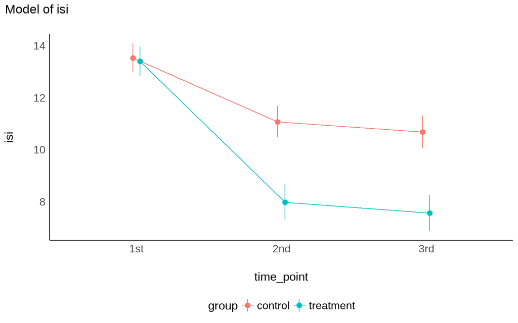

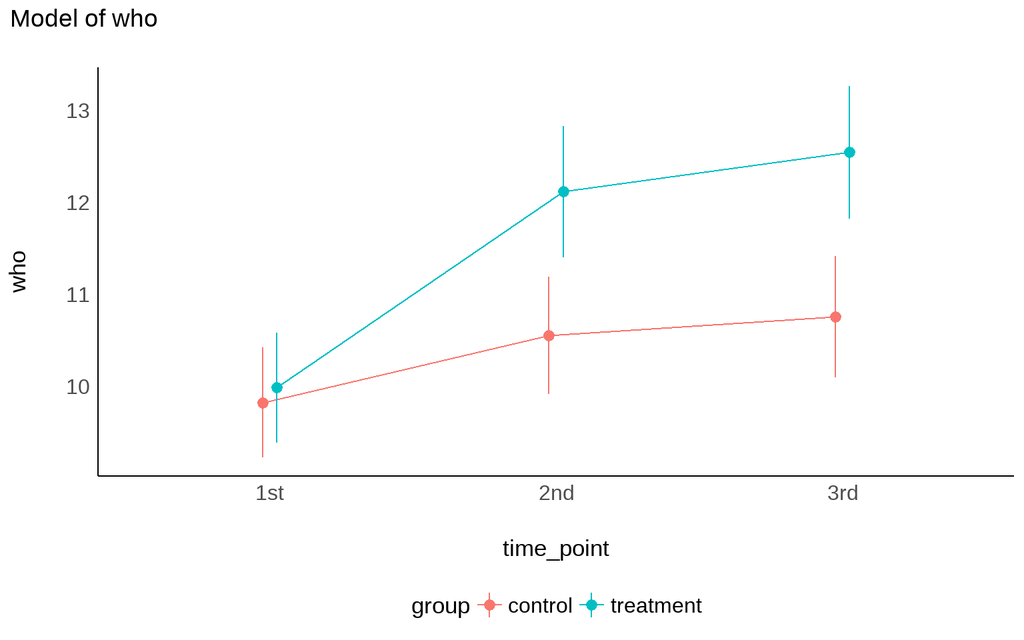

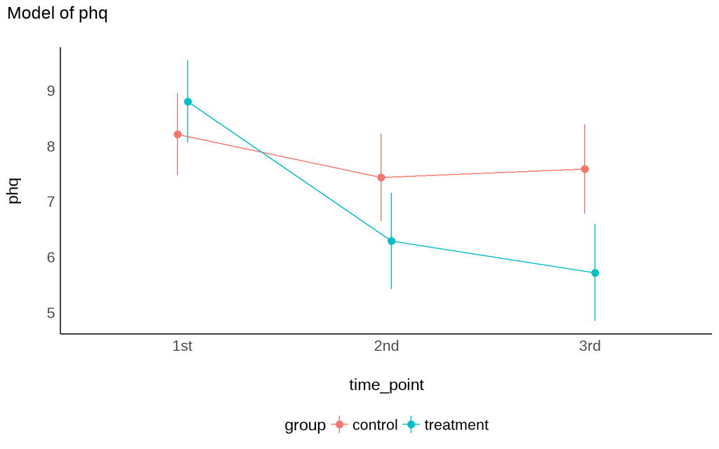

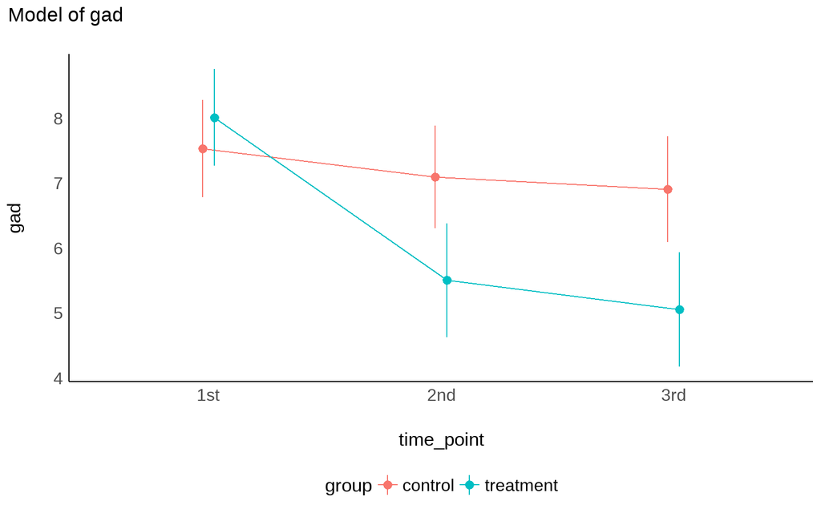

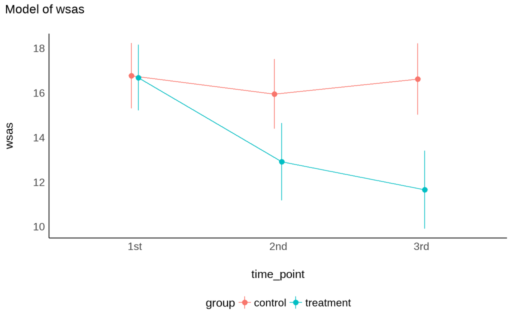

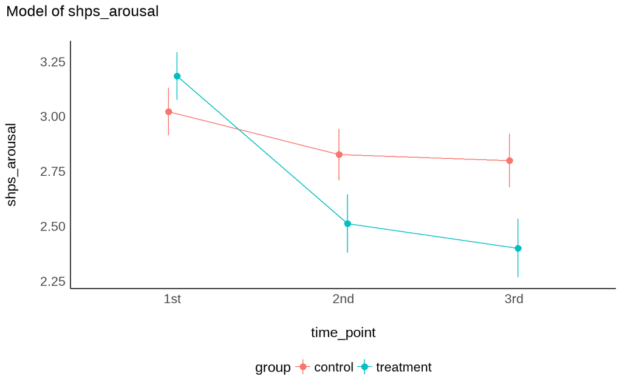

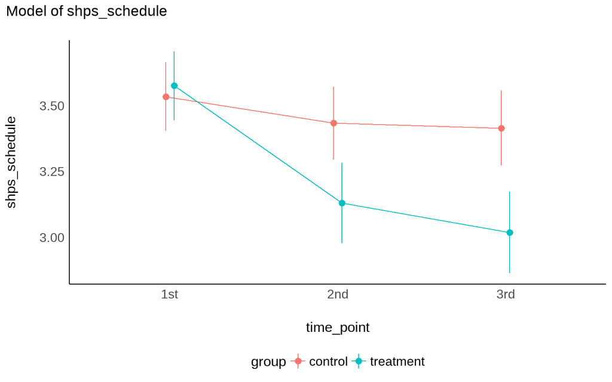

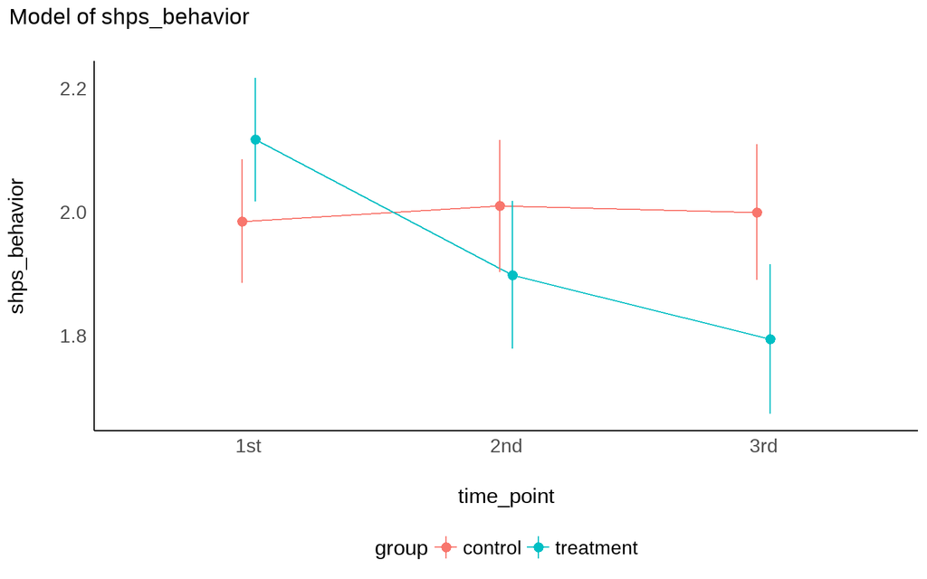

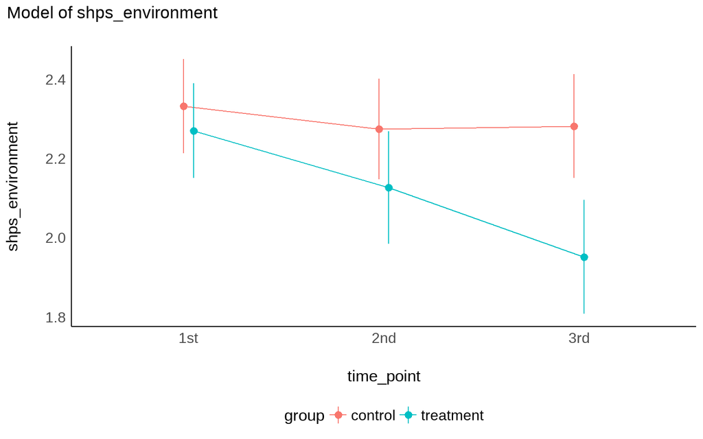

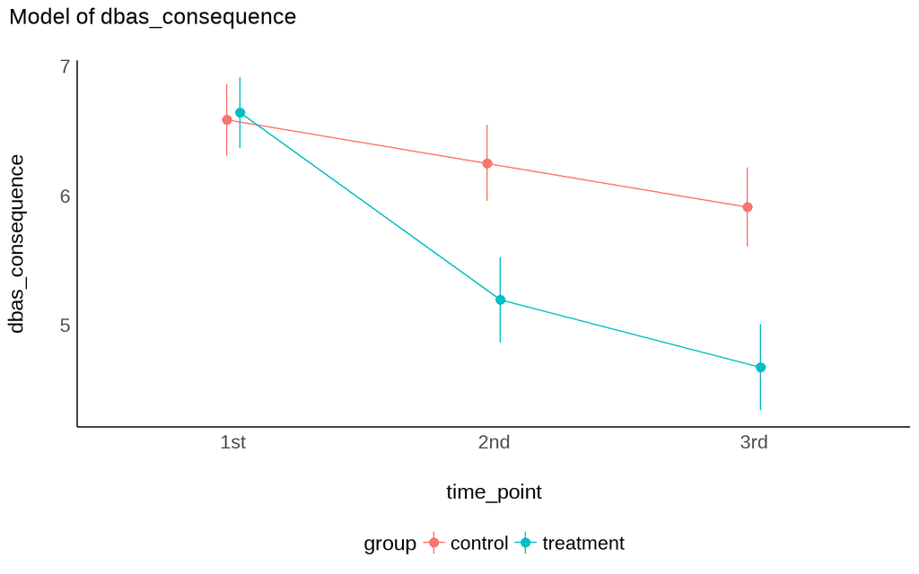

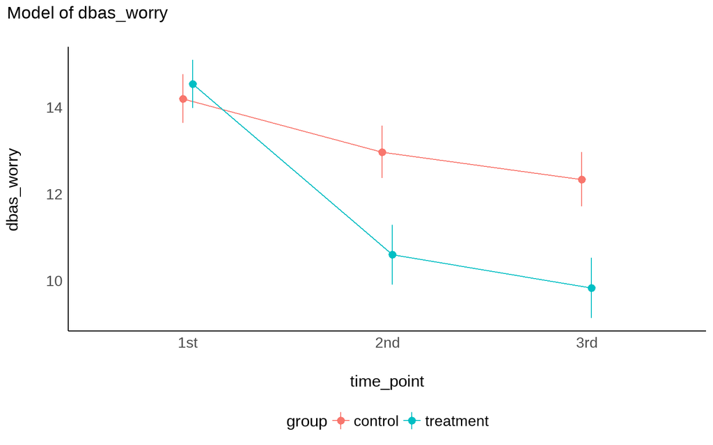

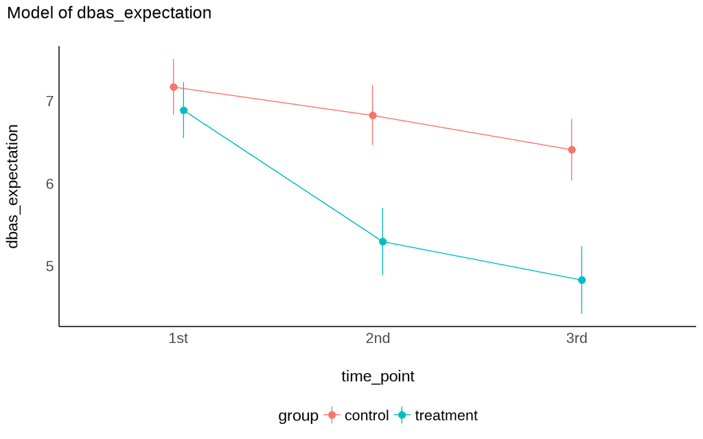

[9 more figures not shown]

## Clinical significance

| outcome | T1 control1 | T1 treatment1 | T1 p-value2 | T2 control1 | T2 treatment1 | T2 p-value2 | T3 control1 | T3 treatment1 | T3 p-value2 |
| --- | --- | --- | --- | --- | --- | --- | --- | --- | --- |
| isi | 89% | 85% | 0.206 | 61% | 31% | 0.000 | 56% | 29% | 0.000 |
| psqi | 96% | 97% | 0.586 | 89% | 74% | 0.003 | 89% | 65% | 0.000 |
| phq | 31% | 38% | 0.148 | 32% | 19% | 0.019 | 30% | 18% | 0.036 |
| gad | 30% | 33% | 0.494 | 26% | 17% | 0.061 | 27% | 16% | 0.049 |
| wsas | 74% | 72% | 0.721 | 68% | 55% | 0.041 | 69% | 49% | 0.001 |

1%  
2Pearson's Chi-squared test